# examples_future

You know the graph $y=f(x)$ has one real root at $x=4$. You are told that another (complex) root is $x=2+{6}i$.

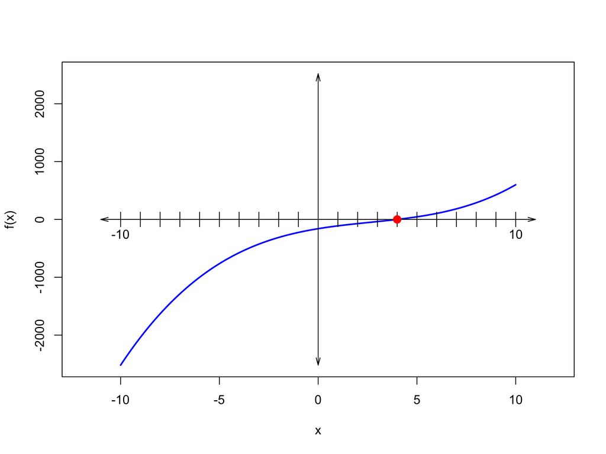

Find $B$, $C$, and $D$.

- $B=$
- $C=$
- $D=$

We know that complex roots come as pairs of complex conjugates. We are told $x=2+{6}i$ is a root, so we also know $x=2-{6}i$ is another root.

Write the cubic polynomial in factored form (based on the three roots).

$$f(x)~=~(x-{4})\cdot\left(x-(2+{6}i)\right)\cdot\left(x-(2-{6}i)\right)$$

I would expand $\left(x-(2+{6}i)\right)\cdot\left(x-(2-{6}i)\right)$ by first distributing across the internal parentheses to get $\left(x-2-{6}i\right)\cdot\left(x-2+{6}i\right)$ and then using the box method to multiply.

| * | $x$ | $-2$ | $-6i$ |
| --- | --- | --- | --- |
| $x$ | $x^2$ | $-2x$ | $-6ix$ |
| $-2$ | $-2x$ | $4$ | $12i$ |
| $6i$ | $6ix$ | $-12i$ | $36$ |

Combine like terms to get:

$$f(x)~=~(x-{4})\cdot\left(x^{2}-{4}x+{40}\right)$$

Now, we multiply again.

| * | $x^2$ | $-4x$ | $40$ |
| --- | --- | --- | --- |
| $x$ | $x^3$ | $-4x^2$ | $40x$ |
| $-4$ | $-4x^2$ | $16x$ | $-160$ |

Combine like terms to get:
$$f(x)~~=~~
x^{3}-{8}x^{2}+{56}x-{160}$$

Thus,

- $B=-8$
- $C=56$
- $D=-160$

A cubic polynomial, $f(x)$, is generated by randomly selecting the three **real** parameters, $B$, $C$, and $D$, in the equation below.

$$f(x)~=~x^3+Bx^2+Cx+D$$

You know the graph $y=f(x)$ has one real root at $x=-1$. You are told that another (complex) root is $x=-1+i$.

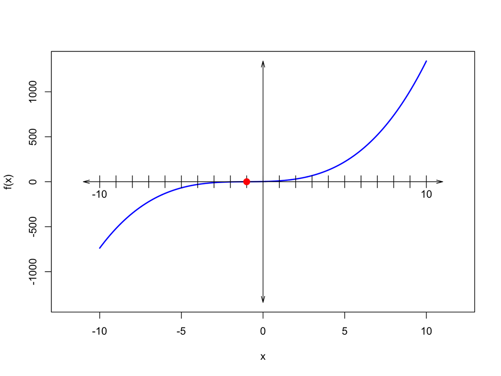

Find $B$, $C$, and $D$.

- $B=$
- $C=$
- $D=$

We know that complex roots come as pairs of complex conjugates. We are told $x=-1+i$ is a root, so we also know $x=-1-i$ is another root.

Write the cubic polynomial in factored form (based on the three roots).

$$f(x)~=~(x+{1})\cdot\left(x-(-1+i)\right)\cdot\left(x-(-1-i)\right)$$

I would expand $\left(x-(-1+i)\right)\cdot\left(x-(-1-i)\right)$ by first distributing across the internal parentheses to get $\left(x+1-i\right)\cdot\left(x+1+i\right)$ and then using the box method to multiply.

| * | $x$ | $1$ | $-1i$ |
| --- | --- | --- | --- |
| $x$ | $x^2$ | $1x$ | $-1ix$ |
| $1$ | $1x$ | $1$ | $-1i$ |
| $1i$ | $1ix$ | $1i$ | $1$ |

Combine like terms to get:

$$f(x)~=~(x+{1})\cdot\left(x^{2}+{2}x+{2}\right)$$

Now, we multiply again.

| * | $x^2$ | $2x$ | $2$ |
| --- | --- | --- | --- |
| $x$ | $x^3$ | $2x^2$ | $2x$ |
| $1$ | $1x^2$ | $2x$ | $2$ |

Combine like terms to get:
$$f(x)~~=~~
x^{3}+{3}x^{2}+{4}x+{2}$$

Thus,

- $B=3$
- $C=4$
- $D=2$

A cubic polynomial, $f(x)$, is generated by randomly selecting the three **real** parameters, $B$, $C$, and $D$, in the equation below.

$$f(x)~=~x^3+Bx^2+Cx+D$$

You know the graph $y=f(x)$ has one real root at $x=-5$. You are told that another (complex) root is $x=3+{4}i$.

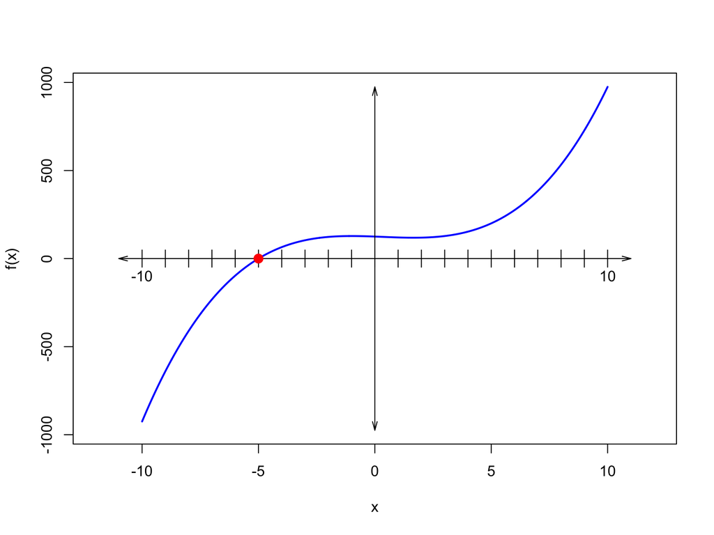

Find $B$, $C$, and $D$.

- $B=$
- $C=$
- $D=$

We know that complex roots come as pairs of complex conjugates. We are told $x=3+{4}i$ is a root, so we also know $x=3-{4}i$ is another root.

Write the cubic polynomial in factored form (based on the three roots).

$$f(x)~=~(x+{5})\cdot\left(x-(3+{4}i)\right)\cdot\left(x-(3-{4}i)\right)$$

I would expand $\left(x-(3+{4}i)\right)\cdot\left(x-(3-{4}i)\right)$ by first distributing across the internal parentheses to get $\left(x-3-{4}i\right)\cdot\left(x-3+{4}i\right)$ and then using the box method to multiply.

| * | $x$ | $-3$ | $-4i$ |
| --- | --- | --- | --- |
| $x$ | $x^2$ | $-3x$ | $-4ix$ |
| $-3$ | $-3x$ | $9$ | $12i$ |
| $4i$ | $4ix$ | $-12i$ | $16$ |

Combine like terms to get:

$$f(x)~=~(x+{5})\cdot\left(x^{2}-{6}x+{25}\right)$$

Now, we multiply again.

| * | $x^2$ | $-6x$ | $25$ |
| --- | --- | --- | --- |
| $x$ | $x^3$ | $-6x^2$ | $25x$ |
| $5$ | $5x^2$ | $-30x$ | $125$ |

Combine like terms to get:
$$f(x)~~=~~
x^{3}-x^{2}-{5}x+{125}$$

Thus,

- $B=-1$
- $C=-5$
- $D=125$

A cubic polynomial, $f(x)$, is generated by randomly selecting the three **real** parameters, $B$, $C$, and $D$, in the equation below.

$$f(x)~=~x^3+Bx^2+Cx+D$$

You know the graph $y=f(x)$ has one real root at $x=3$. You are told that another (complex) root is $x=5+i$.

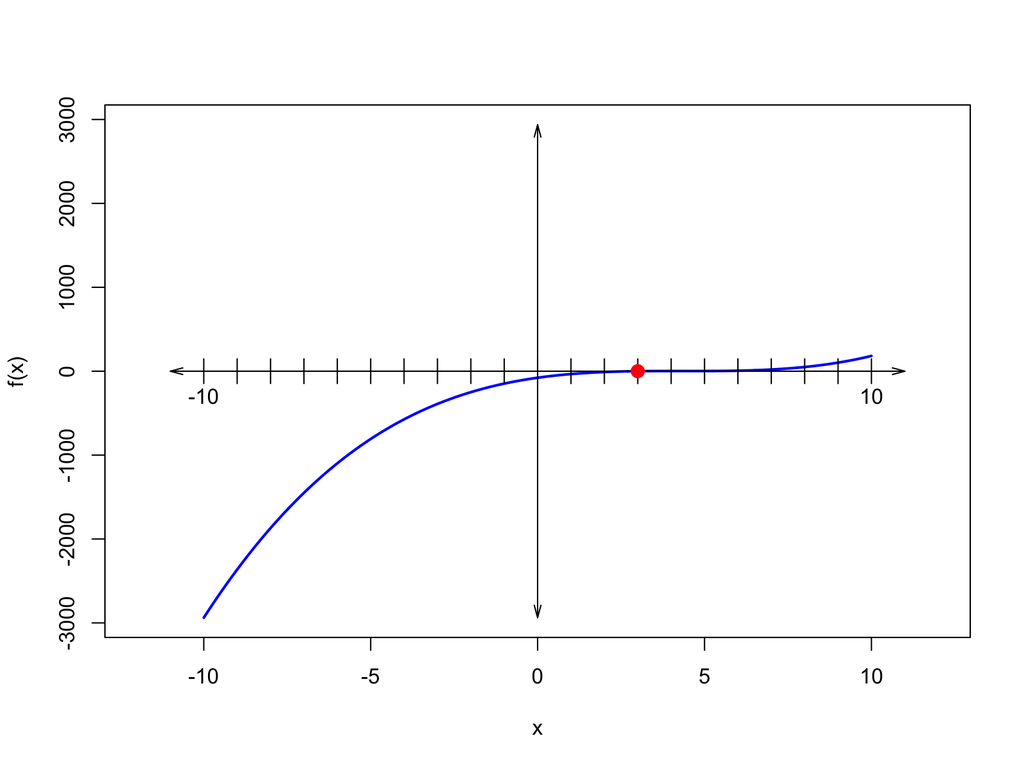

Find $B$, $C$, and $D$.

- $B=$
- $C=$
- $D=$

We know that complex roots come as pairs of complex conjugates. We are told $x=5+i$ is a root, so we also know $x=5-i$ is another root.

Write the cubic polynomial in factored form (based on the three roots).

$$f(x)~=~(x-{3})\cdot\left(x-(5+i)\right)\cdot\left(x-(5-i)\right)$$

I would expand $\left(x-(5+i)\right)\cdot\left(x-(5-i)\right)$ by first distributing across the internal parentheses to get $\left(x-5-i\right)\cdot\left(x-5+i\right)$ and then using the box method to multiply.

| * | $x$ | $-5$ | $-1i$ |
| --- | --- | --- | --- |
| $x$ | $x^2$ | $-5x$ | $-1ix$ |
| $-5$ | $-5x$ | $25$ | $5i$ |
| $1i$ | $1ix$ | $-5i$ | $1$ |

Combine like terms to get:

$$f(x)~=~(x-{3})\cdot\left(x^{2}-{10}x+{26}\right)$$

Now, we multiply again.

| * | $x^2$ | $-10x$ | $26$ |
| --- | --- | --- | --- |
| $x$ | $x^3$ | $-10x^2$ | $26x$ |
| $-3$ | $-3x^2$ | $30x$ | $-78$ |

Combine like terms to get:
$$f(x)~~=~~
x^{3}-{13}x^{2}+{56}x-{78}$$

Thus,

- $B=-13$
- $C=56$
- $D=-78$

A cubic polynomial, $f(x)$, is generated by randomly selecting the three **real** parameters, $B$, $C$, and $D$, in the equation below.

$$f(x)~=~x^3+Bx^2+Cx+D$$

You know the graph $y=f(x)$ has one real root at $x=-1$. You are told that another (complex) root is $x=4+{4}i$.

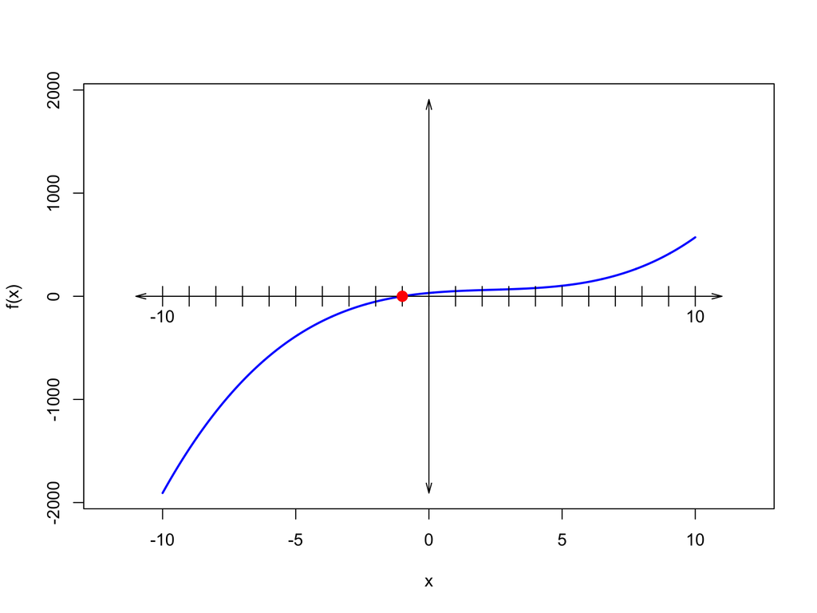

Find $B$, $C$, and $D$.

- $B=$
- $C=$
- $D=$

We know that complex roots come as pairs of complex conjugates. We are told $x=4+{4}i$ is a root, so we also know $x=4-{4}i$ is another root.

Write the cubic polynomial in factored form (based on the three roots).

$$f(x)~=~(x+{1})\cdot\left(x-(4+{4}i)\right)\cdot\left(x-(4-{4}i)\right)$$

I would expand $\left(x-(4+{4}i)\right)\cdot\left(x-(4-{4}i)\right)$ by first distributing across the internal parentheses to get $\left(x-4-{4}i\right)\cdot\left(x-4+{4}i\right)$ and then using the box method to multiply.

| * | $x$ | $-4$ | $-4i$ |
| --- | --- | --- | --- |
| $x$ | $x^2$ | $-4x$ | $-4ix$ |
| $-4$ | $-4x$ | $16$ | $16i$ |
| $4i$ | $4ix$ | $-16i$ | $16$ |

Combine like terms to get:

$$f(x)~=~(x+{1})\cdot\left(x^{2}-{8}x+{32}\right)$$

Now, we multiply again.

| * | $x^2$ | $-8x$ | $32$ |
| --- | --- | --- | --- |
| $x$ | $x^3$ | $-8x^2$ | $32x$ |
| $1$ | $1x^2$ | $-8x$ | $32$ |

Combine like terms to get:
$$f(x)~~=~~
x^{3}-{7}x^{2}+{24}x+{32}$$

Thus,

- $B=-7$
- $C=24$
- $D=32$

A cubic polynomial, $f(x)$, is generated by randomly selecting the three **real** parameters, $B$, $C$, and $D$, in the equation below.

$$f(x)~=~x^3+Bx^2+Cx+D$$

You know the graph $y=f(x)$ has one real root at $x=-6$. You are told that another (complex) root is $x=3+i$.

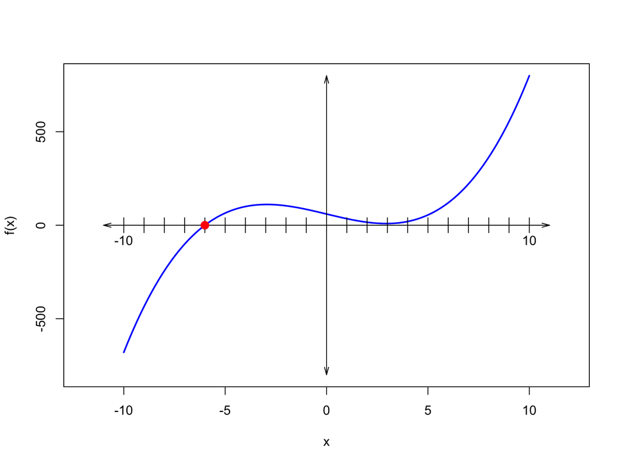

Find $B$, $C$, and $D$.

- $B=$
- $C=$
- $D=$

We know that complex roots come as pairs of complex conjugates. We are told $x=3+i$ is a root, so we also know $x=3-i$ is another root.

Write the cubic polynomial in factored form (based on the three roots).

$$f(x)~=~(x+{6})\cdot\left(x-(3+i)\right)\cdot\left(x-(3-i)\right)$$

I would expand $\left(x-(3+i)\right)\cdot\left(x-(3-i)\right)$ by first distributing across the internal parentheses to get $\left(x-3-i\right)\cdot\left(x-3+i\right)$ and then using the box method to multiply.

| * | $x$ | $-3$ | $-1i$ |
| --- | --- | --- | --- |
| $x$ | $x^2$ | $-3x$ | $-1ix$ |
| $-3$ | $-3x$ | $9$ | $3i$ |
| $1i$ | $1ix$ | $-3i$ | $1$ |

Combine like terms to get:

$$f(x)~=~(x+{6})\cdot\left(x^{2}-{6}x+{10}\right)$$

Now, we multiply again.

| * | $x^2$ | $-6x$ | $10$ |
| --- | --- | --- | --- |
| $x$ | $x^3$ | $-6x^2$ | $10x$ |
| $6$ | $6x^2$ | $-36x$ | $60$ |

Combine like terms to get:
$$f(x)~~=~~
x^{3}-{26}x+{60}$$

Thus,

- $B=0$
- $C=-26$
- $D=60$

A cubic polynomial, $f(x)$, is generated by randomly selecting the three **real** parameters, $B$, $C$, and $D$, in the equation below.

$$f(x)~=~x^3+Bx^2+Cx+D$$

You know the graph $y=f(x)$ has one real root at $x=-2$. You are told that another (complex) root is $x=1+{3}i$.

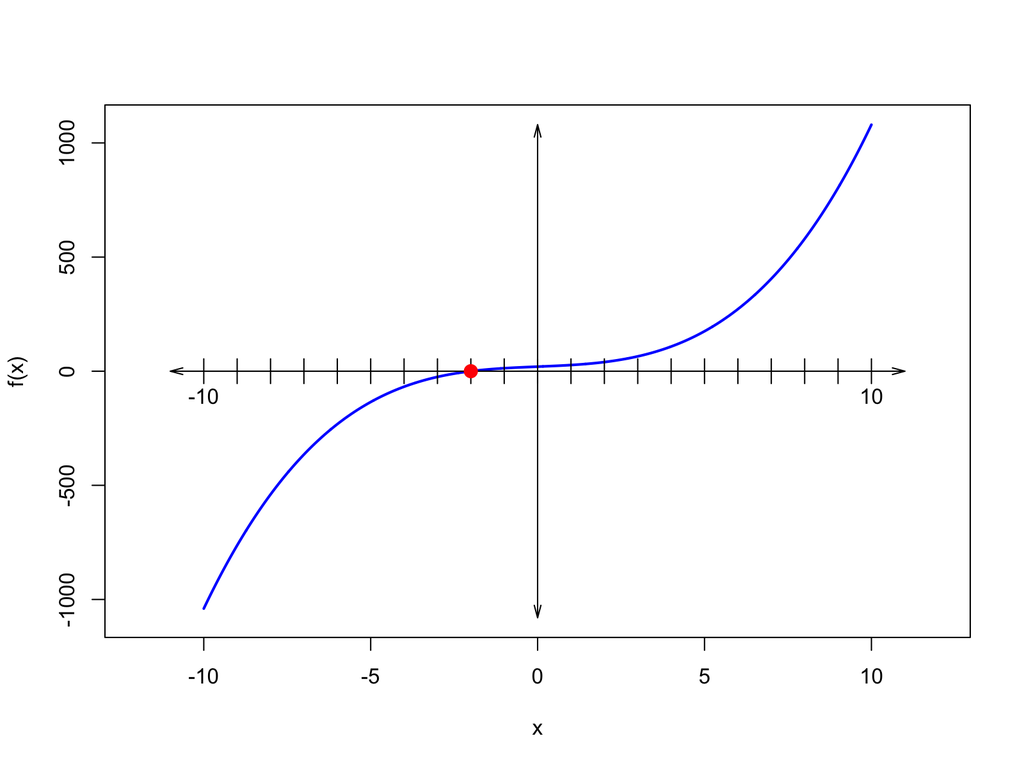

Find $B$, $C$, and $D$.

- $B=$
- $C=$
- $D=$

We know that complex roots come as pairs of complex conjugates. We are told $x=1+{3}i$ is a root, so we also know $x=1-{3}i$ is another root.

Write the cubic polynomial in factored form (based on the three roots).

$$f(x)~=~(x+{2})\cdot\left(x-(1+{3}i)\right)\cdot\left(x-(1-{3}i)\right)$$

I would expand $\left(x-(1+{3}i)\right)\cdot\left(x-(1-{3}i)\right)$ by first distributing across the internal parentheses to get $\left(x-1-{3}i\right)\cdot\left(x-1+{3}i\right)$ and then using the box method to multiply.

| * | $x$ | $-1$ | $-3i$ |
| --- | --- | --- | --- |
| $x$ | $x^2$ | $-1x$ | $-3ix$ |
| $-1$ | $-1x$ | $1$ | $3i$ |
| $3i$ | $3ix$ | $-3i$ | $9$ |

Combine like terms to get:

$$f(x)~=~(x+{2})\cdot\left(x^{2}-{2}x+{10}\right)$$

Now, we multiply again.

| * | $x^2$ | $-2x$ | $10$ |
| --- | --- | --- | --- |
| $x$ | $x^3$ | $-2x^2$ | $10x$ |
| $2$ | $2x^2$ | $-4x$ | $20$ |

Combine like terms to get:
$$f(x)~~=~~
x^{3}+{6}x+{20}$$

Thus,

- $B=0$
- $C=6$
- $D=20$

A cubic polynomial, $f(x)$, is generated by randomly selecting the three **real** parameters, $B$, $C$, and $D$, in the equation below.

$$f(x)~=~x^3+Bx^2+Cx+D$$

You know the graph $y=f(x)$ has one real root at $x=-5$. You are told that another (complex) root is $x=-1+{6}i$.

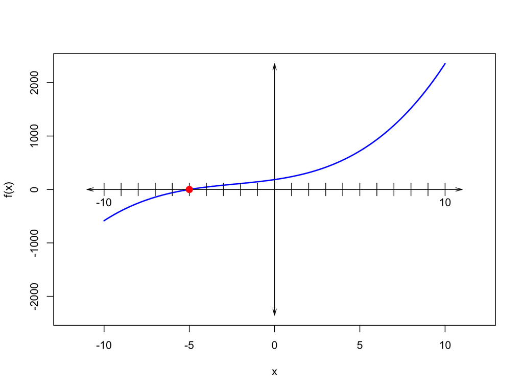

Find $B$, $C$, and $D$.

- $B=$
- $C=$
- $D=$

We know that complex roots come as pairs of complex conjugates. We are told $x=-1+{6}i$ is a root, so we also know $x=-1-{6}i$ is another root.

Write the cubic polynomial in factored form (based on the three roots).

$$f(x)~=~(x+{5})\cdot\left(x-(-1+{6}i)\right)\cdot\left(x-(-1-{6}i)\right)$$

I would expand $\left(x-(-1+{6}i)\right)\cdot\left(x-(-1-{6}i)\right)$ by first distributing across the internal parentheses to get $\left(x+1-{6}i\right)\cdot\left(x+1+{6}i\right)$ and then using the box method to multiply.

| * | $x$ | $1$ | $-6i$ |
| --- | --- | --- | --- |
| $x$ | $x^2$ | $1x$ | $-6ix$ |
| $1$ | $1x$ | $1$ | $-6i$ |
| $6i$ | $6ix$ | $6i$ | $36$ |

Combine like terms to get:

$$f(x)~=~(x+{5})\cdot\left(x^{2}+{2}x+{37}\right)$$

Now, we multiply again.

| * | $x^2$ | $2x$ | $37$ |
| --- | --- | --- | --- |
| $x$ | $x^3$ | $2x^2$ | $37x$ |
| $5$ | $5x^2$ | $10x$ | $185$ |

Combine like terms to get:
$$f(x)~~=~~
x^{3}+{7}x^{2}+{47}x+{185}$$

Thus,

- $B=7$
- $C=47$
- $D=185$

A cubic polynomial, $f(x)$, is generated by randomly selecting the three **real** parameters, $B$, $C$, and $D$, in the equation below.

$$f(x)~=~x^3+Bx^2+Cx+D$$

You know the graph $y=f(x)$ has one real root at $x=-6$. You are told that another (complex) root is $x=-5+{5}i$.

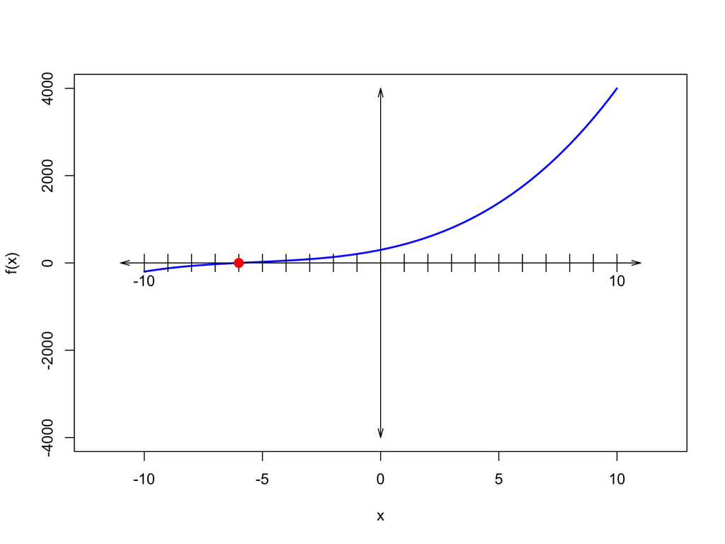

Find $B$, $C$, and $D$.

- $B=$
- $C=$
- $D=$

We know that complex roots come as pairs of complex conjugates. We are told $x=-5+{5}i$ is a root, so we also know $x=-5-{5}i$ is another root.

Write the cubic polynomial in factored form (based on the three roots).

$$f(x)~=~(x+{6})\cdot\left(x-(-5+{5}i)\right)\cdot\left(x-(-5-{5}i)\right)$$

I would expand $\left(x-(-5+{5}i)\right)\cdot\left(x-(-5-{5}i)\right)$ by first distributing across the internal parentheses to get $\left(x+5-{5}i\right)\cdot\left(x+5+{5}i\right)$ and then using the box method to multiply.

| * | $x$ | $5$ | $-5i$ |
| --- | --- | --- | --- |
| $x$ | $x^2$ | $5x$ | $-5ix$ |
| $5$ | $5x$ | $25$ | $-25i$ |
| $5i$ | $5ix$ | $25i$ | $25$ |

Combine like terms to get:

$$f(x)~=~(x+{6})\cdot\left(x^{2}+{10}x+{50}\right)$$

Now, we multiply again.

| * | $x^2$ | $10x$ | $50$ |
| --- | --- | --- | --- |
| $x$ | $x^3$ | $10x^2$ | $50x$ |
| $6$ | $6x^2$ | $60x$ | $300$ |

Combine like terms to get:
$$f(x)~~=~~
x^{3}+{16}x^{2}+{110}x+{300}$$

Thus,

- $B=16$
- $C=110$
- $D=300$

$$f(x) =
-6x^6-10x^5-4x^4+8x^3-3x^2+7x+9$$

### Your answers:

- Left end behavior: $\lim\limits_{x\to-\infty}f(x)=$
- Right end behavior: $\lim\limits_{x\to\infty}f(x)=$

As $x$ heads toward $-\infty$ or $\infty$, the [highest-degree](https://en.wikipedia.org/wiki/Degree_of_a_polynomial) term dominates. So, the end behavior is dictated by the $-6x^6$ term. There are two characteristics of two parameters to consider:

- The sign of the leading coefficient. In this case, -6 is negative.
- The parity of the exponent. In this case, 6 is even.

So,
$$\lim\limits_{x\to-\infty}f(x) =
-6(-\infty)^{6} = (-6)(\infty) = -\infty$$
$$\lim\limits_{x\to\infty}f(x) = -6(\infty)^{6} =
(-6)(\infty) = -\infty$$

$$f(x) =
-9x^8-4x^7+8x^6+7x^5+2x^4-2x^3+6x^2-5x+4$$

### Your answers:

- Left end behavior: $\lim\limits_{x\to-\infty}f(x)=$
- Right end behavior: $\lim\limits_{x\to\infty}f(x)=$

As $x$ heads toward $-\infty$ or $\infty$, the [highest-degree](https://en.wikipedia.org/wiki/Degree_of_a_polynomial) term dominates. So, the end behavior is dictated by the $-9x^8$ term. There are two characteristics of two parameters to consider:

- The sign of the leading coefficient. In this case, -9 is negative.
- The parity of the exponent. In this case, 8 is even.

So,
$$\lim\limits_{x\to-\infty}f(x) =
-9(-\infty)^{8} = (-9)(\infty) = -\infty$$
$$\lim\limits_{x\to\infty}f(x) = -9(\infty)^{8} =
(-9)(\infty) = -\infty$$

$$f(x) =
6x^8+9x^7-9x^6-6x^5+4x^4-4x^3+5x^2-3x+7$$

### Your answers:

- Left end behavior: $\lim\limits_{x\to-\infty}f(x)=$
- Right end behavior: $\lim\limits_{x\to\infty}f(x)=$

As $x$ heads toward $-\infty$ or $\infty$, the [highest-degree](https://en.wikipedia.org/wiki/Degree_of_a_polynomial) term dominates. So, the end behavior is dictated by the $6x^8$ term. There are two characteristics of two parameters to consider:

- The sign of the leading coefficient. In this case, 6 is positive.
- The parity of the exponent. In this case, 8 is even.

So,
$$\lim\limits_{x\to-\infty}f(x) =
6(-\infty)^{8} = (6)(\infty) = \infty$$
$$\lim\limits_{x\to\infty}f(x) = 6(\infty)^{8} =
(6)(\infty) = \infty$$

$$f(x) =
4x^7-9x^6+9x^5+5x^4+2x^3-4x^2+7x-10$$

### Your answers:

- Left end behavior: $\lim\limits_{x\to-\infty}f(x)=$
- Right end behavior: $\lim\limits_{x\to\infty}f(x)=$

As $x$ heads toward $-\infty$ or $\infty$, the [highest-degree](https://en.wikipedia.org/wiki/Degree_of_a_polynomial) term dominates. So, the end behavior is dictated by the $4x^7$ term. There are two characteristics of two parameters to consider:

- The sign of the leading coefficient. In this case, 4 is positive.
- The parity of the exponent. In this case, 7 is odd.

So,
$$\lim\limits_{x\to-\infty}f(x) =
4(-\infty)^{7} = (4)(-\infty) = -\infty$$
$$\lim\limits_{x\to\infty}f(x) = 4(\infty)^{7} =
(4)(\infty) = \infty$$

$$f(x) =
7x^6+10x^5-3x^4-7x^3+6x^2-5x-9$$

### Your answers:

- Left end behavior: $\lim\limits_{x\to-\infty}f(x)=$
- Right end behavior: $\lim\limits_{x\to\infty}f(x)=$

As $x$ heads toward $-\infty$ or $\infty$, the [highest-degree](https://en.wikipedia.org/wiki/Degree_of_a_polynomial) term dominates. So, the end behavior is dictated by the $7x^6$ term. There are two characteristics of two parameters to consider:

- The sign of the leading coefficient. In this case, 7 is positive.
- The parity of the exponent. In this case, 6 is even.

So,
$$\lim\limits_{x\to-\infty}f(x) =
7(-\infty)^{6} = (7)(\infty) = \infty$$
$$\lim\limits_{x\to\infty}f(x) = 7(\infty)^{6} =
(7)(\infty) = \infty$$

$$f(x) =
10x^6+5x^5-3x^4+2x^3+9x^2-10x-6$$

### Your answers:

- Left end behavior: $\lim\limits_{x\to-\infty}f(x)=$
- Right end behavior: $\lim\limits_{x\to\infty}f(x)=$

As $x$ heads toward $-\infty$ or $\infty$, the [highest-degree](https://en.wikipedia.org/wiki/Degree_of_a_polynomial) term dominates. So, the end behavior is dictated by the $10x^6$ term. There are two characteristics of two parameters to consider:

- The sign of the leading coefficient. In this case, 10 is positive.
- The parity of the exponent. In this case, 6 is even.

So,
$$\lim\limits_{x\to-\infty}f(x) =
10(-\infty)^{6} = (10)(\infty) = \infty$$
$$\lim\limits_{x\to\infty}f(x) = 10(\infty)^{6} =
(10)(\infty) = \infty$$

$$f(x) =
-2x^7-3x^6-10x^5-7x^4+10x^3+6x^2-6x+3$$

### Your answers:

- Left end behavior: $\lim\limits_{x\to-\infty}f(x)=$
- Right end behavior: $\lim\limits_{x\to\infty}f(x)=$

As $x$ heads toward $-\infty$ or $\infty$, the [highest-degree](https://en.wikipedia.org/wiki/Degree_of_a_polynomial) term dominates. So, the end behavior is dictated by the $-2x^7$ term. There are two characteristics of two parameters to consider:

- The sign of the leading coefficient. In this case, -2 is negative.
- The parity of the exponent. In this case, 7 is odd.

So,
$$\lim\limits_{x\to-\infty}f(x) =
-2(-\infty)^{7} = (-2)(-\infty) = \infty$$
$$\lim\limits_{x\to\infty}f(x) = -2(\infty)^{7} =
(-2)(\infty) = -\infty$$

$$f(x) =
7x^8-9x^7-4x^6+9x^5-5x^4+6x^3-3x^2-10x-7$$

### Your answers:

- Left end behavior: $\lim\limits_{x\to-\infty}f(x)=$
- Right end behavior: $\lim\limits_{x\to\infty}f(x)=$

As $x$ heads toward $-\infty$ or $\infty$, the [highest-degree](https://en.wikipedia.org/wiki/Degree_of_a_polynomial) term dominates. So, the end behavior is dictated by the $7x^8$ term. There are two characteristics of two parameters to consider:

- The sign of the leading coefficient. In this case, 7 is positive.
- The parity of the exponent. In this case, 8 is even.

So,
$$\lim\limits_{x\to-\infty}f(x) =
7(-\infty)^{8} = (7)(\infty) = \infty$$
$$\lim\limits_{x\to\infty}f(x) = 7(\infty)^{8} =
(7)(\infty) = \infty$$

$$f(x) =
-7x^6-2x^5-6x^4+9x^3+4x^2+3x-9$$

### Your answers:

- Left end behavior: $\lim\limits_{x\to-\infty}f(x)=$
- Right end behavior: $\lim\limits_{x\to\infty}f(x)=$

As $x$ heads toward $-\infty$ or $\infty$, the [highest-degree](https://en.wikipedia.org/wiki/Degree_of_a_polynomial) term dominates. So, the end behavior is dictated by the $-7x^6$ term. There are two characteristics of two parameters to consider:

- The sign of the leading coefficient. In this case, -7 is negative.
- The parity of the exponent. In this case, 6 is even.

So,
$$\lim\limits_{x\to-\infty}f(x) =
-7(-\infty)^{6} = (-7)(\infty) = -\infty$$
$$\lim\limits_{x\to\infty}f(x) = -7(\infty)^{6} =
(-7)(\infty) = -\infty$$

$$f(x) =
-8x^8+10x^7+6x^6+4x^5+9x^4+7x^3+3x^2-3x-2$$

### Your answers:

- Left end behavior: $\lim\limits_{x\to-\infty}f(x)=$
- Right end behavior: $\lim\limits_{x\to\infty}f(x)=$

As $x$ heads toward $-\infty$ or $\infty$, the [highest-degree](https://en.wikipedia.org/wiki/Degree_of_a_polynomial) term dominates. So, the end behavior is dictated by the $-8x^8$ term. There are two characteristics of two parameters to consider:

- The sign of the leading coefficient. In this case, -8 is negative.
- The parity of the exponent. In this case, 8 is even.

So,
$$\lim\limits_{x\to-\infty}f(x) =
-8(-\infty)^{8} = (-8)(\infty) = -\infty$$
$$\lim\limits_{x\to\infty}f(x) = -8(\infty)^{8} =
(-8)(\infty) = -\infty$$

There are four types of end behavior in polynomials (seen by zooming out on the graph and looking far left or far right):

**For each polynomial, state the end behavior.**

1. $f(x)~=~{4}x^{6}-{7}x^{5}+{2}x^{4}-{9}x^{3}+{3}x^{2}+{6}x$
- End behavior for $f(x)$ is .
2. $g(x)~=~{-6}x^{7}+{3}x^{6}+{9}x^{5}-{2}x^{4}+{2}x^{3}+{4}x^{2}-{6}x$
- End behavior for $g(x)$ is .
3. $h(x)~=~{-2}x^{6}-{8}x^{5}+{5}x^{4}+{6}x^{3}-{7}x^{2}-x+{4}$
- End behavior for $h(x)$ is .
4. $i(x)~=~{-2}x^{8}+{5}x^{7}-{7}x^{6}+x^{5}-{3}x^{4}-{5}x^{3}+{8}x^{2}+{2}x-{4}$
- End behavior for $i(x)$ is .
5. $j(x)~=~-x^{5}-{4}x^{4}+x^{3}+{9}x^{2}-{7}x+{2}$
- End behavior for $j(x)$ is .
6. $k(x)~=~x^{6}+{2}x^{5}+{3}x^{4}-{4}x^{3}-x^{2}+x-{5}$
- End behavior for $k(x)$ is .
7. $l(x)~=~{-5}x^{6}-x^{5}+{7}x^{4}+{3}x^{3}+{5}x^{2}-{2}x+{9}$
- End behavior for $l(x)$ is .
8. $m(x)~=~{-8}x^{5}+{6}x^{4}-{3}x^{3}-{5}x^{2}-{9}x-{8}$
- End behavior for $m(x)$ is .

For each polynomial, consider the highest-degree term.

|  | lead degree even | lead degree odd |
| --- | --- | --- |
| lead coefficient positive | up,up | down,up |
| lead coefficient negative | down,down | up,down |

1. The highest-degree term of $f(x)$ is ${4}x^{6}$. The coefficient is positive. The degree is even. Thus, the end behavior is up,up.
2. The highest-degree term of $g(x)$ is ${-6}x^{7}$. The coefficient is negative. The degree is odd. Thus, the end behavior is up,down.
3. The highest-degree term of $h(x)$ is ${-2}x^{6}$. The coefficient is negative. The degree is even. Thus, the end behavior is down,down.
4. The highest-degree term of $i(x)$ is ${-2}x^{8}$. The coefficient is negative. The degree is even. Thus, the end behavior is down,down.
5. The highest-degree term of $j(x)$ is $-x^{5}$. The coefficient is negative. The degree is odd. Thus, the end behavior is up,down.
6. The highest-degree term of $k(x)$ is $x^{6}$. The coefficient is positive. The degree is even. Thus, the end behavior is up,up.
7. The highest-degree term of $l(x)$ is ${-5}x^{6}$. The coefficient is negative. The degree is even. Thus, the end behavior is down,down.
8. The highest-degree term of $m(x)$ is ${-8}x^{5}$. The coefficient is negative. The degree is odd. Thus, the end behavior is up,down.

There are four types of end behavior in polynomials (seen by zooming out on the graph and looking far left or far right):

**For each polynomial, state the end behavior.**

1. $f(x)~=~{-2}x^{8}-{5}x^{6}+{8}x^{5}-{9}x^{4}-{3}x^{3}-{2}x^{2}+{9}x-{1}$
- End behavior for $f(x)$ is .
2. $g(x)~=~{9}x^{7}+{8}x^{6}+{7}x^{5}+{4}x^{4}+x^{3}-{4}x^{2}-{9}x+{5}$
- End behavior for $g(x)$ is .
3. $h(x)~=~{-8}x^{6}-{6}x^{5}-{3}x^{4}+{8}x^{3}+{6}x^{2}-{4}x-{5}$
- End behavior for $h(x)$ is .
4. $i(x)~=~-x^{5}+x^{4}+{2}x^{3}-x-{3}$
- End behavior for $i(x)$ is .
5. $j(x)~=~{-8}x^{6}+{4}x^{5}-{5}x^{4}-x^{2}+{7}x-{6}$
- End behavior for $j(x)$ is .
6. $k(x)~=~{5}x^{6}-{2}x^{5}+{2}x^{4}+{8}x^{3}+x^{2}-{7}x-{3}$
- End behavior for $k(x)$ is .
7. $l(x)~=~{2}x^{5}+{3}x^{4}-{6}x^{3}+{9}x^{2}-{3}x-{4}$
- End behavior for $l(x)$ is .
8. $m(x)~=~{6}x^{5}+{4}x^{4}-{7}x^{3}-{2}x^{2}-{4}x-{3}$
- End behavior for $m(x)$ is .

For each polynomial, consider the highest-degree term.

|  | lead degree even | lead degree odd |
| --- | --- | --- |
| lead coefficient positive | up,up | down,up |
| lead coefficient negative | down,down | up,down |

1. The highest-degree term of $f(x)$ is ${-2}x^{8}$. The coefficient is negative. The degree is even. Thus, the end behavior is down,down.
2. The highest-degree term of $g(x)$ is ${9}x^{7}$. The coefficient is positive. The degree is odd. Thus, the end behavior is down,up.
3. The highest-degree term of $h(x)$ is ${-8}x^{6}$. The coefficient is negative. The degree is even. Thus, the end behavior is down,down.
4. The highest-degree term of $i(x)$ is $-x^{5}$. The coefficient is negative. The degree is odd. Thus, the end behavior is up,down.
5. The highest-degree term of $j(x)$ is ${-8}x^{6}$. The coefficient is negative. The degree is even. Thus, the end behavior is down,down.
6. The highest-degree term of $k(x)$ is ${5}x^{6}$. The coefficient is positive. The degree is even. Thus, the end behavior is up,up.
7. The highest-degree term of $l(x)$ is ${2}x^{5}$. The coefficient is positive. The degree is odd. Thus, the end behavior is down,up.
8. The highest-degree term of $m(x)$ is ${6}x^{5}$. The coefficient is positive. The degree is odd. Thus, the end behavior is down,up.

There are four types of end behavior in polynomials (seen by zooming out on the graph and looking far left or far right):

**For each polynomial, state the end behavior.**

1. $f(x)~=~x^{7}-{5}x^{6}-{7}x^{5}+{7}x^{4}-{2}x^{3}-{9}x^{2}-{8}x+{1}$
- End behavior for $f(x)$ is .
2. $g(x)~=~{-8}x^{5}+{6}x^{4}-{3}x^{3}+{2}x^{2}-x+{3}$
- End behavior for $g(x)$ is .
3. $h(x)~=~{-4}x^{5}-x^{3}+{3}x^{2}-{9}x+{8}$
- End behavior for $h(x)$ is .
4. $i(x)~=~-x^{7}+{9}x^{5}-{2}x^{4}-{3}x^{3}+{7}x^{2}-x-{6}$
- End behavior for $i(x)$ is .
5. $j(x)~=~{5}x^{5}+{7}x^{4}+{2}x^{3}+{5}x^{2}-{1}$
- End behavior for $j(x)$ is .
6. $k(x)~=~{-7}x^{5}+{6}x^{4}+{2}x^{3}-{9}x^{2}+{5}x-{6}$
- End behavior for $k(x)$ is .
7. $l(x)~=~{8}x^{8}+x^{7}-{9}x^{6}-{2}x^{5}+{4}x^{4}+{2}x^{3}-{4}x^{2}+{5}x+{9}$
- End behavior for $l(x)$ is .
8. $m(x)~=~{8}x^{7}+{3}x^{6}-{6}x^{5}+{7}x^{4}-x^{3}+{4}x^{2}+x+{2}$
- End behavior for $m(x)$ is .

For each polynomial, consider the highest-degree term.

|  | lead degree even | lead degree odd |
| --- | --- | --- |
| lead coefficient positive | up,up | down,up |
| lead coefficient negative | down,down | up,down |

1. The highest-degree term of $f(x)$ is $x^{7}$. The coefficient is positive. The degree is odd. Thus, the end behavior is down,up.
2. The highest-degree term of $g(x)$ is ${-8}x^{5}$. The coefficient is negative. The degree is odd. Thus, the end behavior is up,down.
3. The highest-degree term of $h(x)$ is ${-4}x^{5}$. The coefficient is negative. The degree is odd. Thus, the end behavior is up,down.
4. The highest-degree term of $i(x)$ is $-x^{7}$. The coefficient is negative. The degree is odd. Thus, the end behavior is up,down.
5. The highest-degree term of $j(x)$ is ${5}x^{5}$. The coefficient is positive. The degree is odd. Thus, the end behavior is down,up.
6. The highest-degree term of $k(x)$ is ${-7}x^{5}$. The coefficient is negative. The degree is odd. Thus, the end behavior is up,down.
7. The highest-degree term of $l(x)$ is ${8}x^{8}$. The coefficient is positive. The degree is even. Thus, the end behavior is up,up.
8. The highest-degree term of $m(x)$ is ${8}x^{7}$. The coefficient is positive. The degree is odd. Thus, the end behavior is down,up.

There are four types of end behavior in polynomials (seen by zooming out on the graph and looking far left or far right):

**For each polynomial, state the end behavior.**

1. $f(x)~=~{-8}x^{5}+{3}x^{4}+{7}x^{3}+{4}x^{2}-{8}x$
- End behavior for $f(x)$ is .
2. $g(x)~=~{-2}x^{8}+{7}x^{7}+{8}x^{6}+x^{5}+{4}x^{4}-x^{2}-{5}x-{9}$
- End behavior for $g(x)$ is .
3. $h(x)~=~{5}x^{6}+{2}x^{5}+{9}x^{4}-{3}x^{3}+{4}x^{2}+x$
- End behavior for $h(x)$ is .
4. $i(x)~=~{4}x^{7}-{5}x^{6}+{3}x^{5}+{9}x^{4}-{6}x^{3}-{9}x^{2}-x+{2}$
- End behavior for $i(x)$ is .
5. $j(x)~=~{2}x^{8}+{6}x^{7}-{7}x^{6}+{7}x^{5}-{4}x^{4}-{8}x^{3}-{2}x^{2}+{9}x-{3}$
- End behavior for $j(x)$ is .
6. $k(x)~=~{3}x^{8}-{5}x^{7}+{2}x^{6}+x^{5}-{4}x^{4}-{2}x^{3}+{3}x^{2}-{3}x+{7}$
- End behavior for $k(x)$ is .
7. $l(x)~=~{-2}x^{8}-{6}x^{6}+{2}x^{5}+{8}x^{4}+{3}x^{3}-x^{2}-{3}x+{4}$
- End behavior for $l(x)$ is .
8. $m(x)~=~{3}x^{8}-{4}x^{7}-{3}x^{6}+x^{5}+{3}x^{4}+{2}x^{3}-{5}x^{2}+{6}x-{7}$
- End behavior for $m(x)$ is .

For each polynomial, consider the highest-degree term.

|  | lead degree even | lead degree odd |
| --- | --- | --- |
| lead coefficient positive | up,up | down,up |
| lead coefficient negative | down,down | up,down |

1. The highest-degree term of $f(x)$ is ${-8}x^{5}$. The coefficient is negative. The degree is odd. Thus, the end behavior is up,down.
2. The highest-degree term of $g(x)$ is ${-2}x^{8}$. The coefficient is negative. The degree is even. Thus, the end behavior is down,down.
3. The highest-degree term of $h(x)$ is ${5}x^{6}$. The coefficient is positive. The degree is even. Thus, the end behavior is up,up.
4. The highest-degree term of $i(x)$ is ${4}x^{7}$. The coefficient is positive. The degree is odd. Thus, the end behavior is down,up.
5. The highest-degree term of $j(x)$ is ${2}x^{8}$. The coefficient is positive. The degree is even. Thus, the end behavior is up,up.
6. The highest-degree term of $k(x)$ is ${3}x^{8}$. The coefficient is positive. The degree is even. Thus, the end behavior is up,up.
7. The highest-degree term of $l(x)$ is ${-2}x^{8}$. The coefficient is negative. The degree is even. Thus, the end behavior is down,down.
8. The highest-degree term of $m(x)$ is ${3}x^{8}$. The coefficient is positive. The degree is even. Thus, the end behavior is up,up.

There are four types of end behavior in polynomials (seen by zooming out on the graph and looking far left or far right):

**For each polynomial, state the end behavior.**

1. $f(x)~=~{-5}x^{8}+{2}x^{7}-{6}x^{6}-x^{5}-{4}x^{4}+{7}x^{3}+x^{2}+{5}x-{2}$
- End behavior for $f(x)$ is .
2. $g(x)~=~{5}x^{8}-x^{7}+{6}x^{6}-{5}x^{5}+{3}x^{4}+{4}x^{3}+{8}x^{2}-{2}x-{6}$
- End behavior for $g(x)$ is .
3. $h(x)~=~{-7}x^{5}-{4}x^{4}-x^{3}+x+{4}$
- End behavior for $h(x)$ is .
4. $i(x)~=~x^{8}-{4}x^{7}-{8}x^{6}-{5}x^{5}+{5}x^{4}+{3}x^{3}+{6}x^{2}-{6}x+{2}$
- End behavior for $i(x)$ is .
5. $j(x)~=~{-3}x^{6}+{7}x^{5}-{8}x^{4}+{6}x^{3}+{3}x^{2}-{6}x-{4}$
- End behavior for $j(x)$ is .
6. $k(x)~=~{-9}x^{5}-{3}x^{4}+{7}x^{3}-{8}x^{2}+{3}x-{7}$
- End behavior for $k(x)$ is .
7. $l(x)~=~{-9}x^{8}+{6}x^{7}-{4}x^{6}+{7}x^{5}+{5}x^{4}-{9}x^{3}+{3}x^{2}-{2}x-{1}$
- End behavior for $l(x)$ is .
8. $m(x)~=~{4}x^{5}+{6}x^{4}-x^{3}+{3}x^{2}+x-{8}$
- End behavior for $m(x)$ is .

For each polynomial, consider the highest-degree term.

|  | lead degree even | lead degree odd |
| --- | --- | --- |
| lead coefficient positive | up,up | down,up |
| lead coefficient negative | down,down | up,down |

1. The highest-degree term of $f(x)$ is ${-5}x^{8}$. The coefficient is negative. The degree is even. Thus, the end behavior is down,down.
2. The highest-degree term of $g(x)$ is ${5}x^{8}$. The coefficient is positive. The degree is even. Thus, the end behavior is up,up.
3. The highest-degree term of $h(x)$ is ${-7}x^{5}$. The coefficient is negative. The degree is odd. Thus, the end behavior is up,down.
4. The highest-degree term of $i(x)$ is $x^{8}$. The coefficient is positive. The degree is even. Thus, the end behavior is up,up.
5. The highest-degree term of $j(x)$ is ${-3}x^{6}$. The coefficient is negative. The degree is even. Thus, the end behavior is down,down.
6. The highest-degree term of $k(x)$ is ${-9}x^{5}$. The coefficient is negative. The degree is odd. Thus, the end behavior is up,down.
7. The highest-degree term of $l(x)$ is ${-9}x^{8}$. The coefficient is negative. The degree is even. Thus, the end behavior is down,down.
8. The highest-degree term of $m(x)$ is ${4}x^{5}$. The coefficient is positive. The degree is odd. Thus, the end behavior is down,up.

There are four types of end behavior in polynomials (seen by zooming out on the graph and looking far left or far right):

**For each polynomial, state the end behavior.**

1. $f(x)~=~{-4}x^{5}-{9}x^{4}+{6}x^{3}+{5}x^{2}-{8}$
- End behavior for $f(x)$ is .
2. $g(x)~=~{2}x^{8}+{8}x^{6}+x^{5}-{8}x^{4}+{7}x^{3}-{6}x^{2}-{4}x-{5}$
- End behavior for $g(x)$ is .
3. $h(x)~=~{5}x^{7}+{3}x^{6}-{8}x^{5}+{2}x^{4}+{7}x^{2}-{6}x-{2}$
- End behavior for $h(x)$ is .
4. $i(x)~=~{8}x^{7}+{7}x^{6}-{7}x^{5}-{5}x^{4}-x^{3}-{4}x^{2}-{9}x-{6}$
- End behavior for $i(x)$ is .
5. $j(x)~=~{3}x^{5}-{7}x^{4}+{9}x^{3}+{6}x^{2}-{2}$
- End behavior for $j(x)$ is .
6. $k(x)~=~{-9}x^{8}+{3}x^{7}-{3}x^{6}+x^{5}-{4}x^{4}+{6}x^{3}-{5}x^{2}-{7}x$
- End behavior for $k(x)$ is .
7. $l(x)~=~{2}x^{6}-{9}x^{5}+{3}x^{4}+{4}x^{3}+x^{2}-x+{9}$
- End behavior for $l(x)$ is .
8. $m(x)~=~{9}x^{7}-{9}x^{6}-{5}x^{5}+{3}x^{4}-{6}x^{3}+{9}x^{2}-{4}$
- End behavior for $m(x)$ is .

For each polynomial, consider the highest-degree term.

|  | lead degree even | lead degree odd |
| --- | --- | --- |
| lead coefficient positive | up,up | down,up |
| lead coefficient negative | down,down | up,down |

1. The highest-degree term of $f(x)$ is ${-4}x^{5}$. The coefficient is negative. The degree is odd. Thus, the end behavior is up,down.
2. The highest-degree term of $g(x)$ is ${2}x^{8}$. The coefficient is positive. The degree is even. Thus, the end behavior is up,up.
3. The highest-degree term of $h(x)$ is ${5}x^{7}$. The coefficient is positive. The degree is odd. Thus, the end behavior is down,up.
4. The highest-degree term of $i(x)$ is ${8}x^{7}$. The coefficient is positive. The degree is odd. Thus, the end behavior is down,up.
5. The highest-degree term of $j(x)$ is ${3}x^{5}$. The coefficient is positive. The degree is odd. Thus, the end behavior is down,up.
6. The highest-degree term of $k(x)$ is ${-9}x^{8}$. The coefficient is negative. The degree is even. Thus, the end behavior is down,down.
7. The highest-degree term of $l(x)$ is ${2}x^{6}$. The coefficient is positive. The degree is even. Thus, the end behavior is up,up.
8. The highest-degree term of $m(x)$ is ${9}x^{7}$. The coefficient is positive. The degree is odd. Thus, the end behavior is down,up.

There are four types of end behavior in polynomials (seen by zooming out on the graph and looking far left or far right):

**For each polynomial, state the end behavior.**

1. $f(x)~=~{-2}x^{8}-{5}x^{7}-{9}x^{6}+{6}x^{5}+{9}x^{4}-{3}x^{3}+{8}x-{8}$
- End behavior for $f(x)$ is .
2. $g(x)~=~{3}x^{7}-{3}x^{6}-{4}x^{5}+{5}x^{4}+{3}x^{2}+{8}x-{8}$
- End behavior for $g(x)$ is .
3. $h(x)~=~{-9}x^{7}+{5}x^{6}-x^{5}-{3}x^{4}-{7}x^{3}+{7}x^{2}+{3}x-{5}$
- End behavior for $h(x)$ is .
4. $i(x)~=~{-4}x^{5}-{5}x^{4}-{7}x^{3}+{3}x^{2}+{9}x+{6}$
- End behavior for $i(x)$ is .
5. $j(x)~=~{7}x^{8}-{2}x^{7}+{8}x^{6}-{7}x^{5}+{9}x^{3}+{6}x^{2}+{5}x-{8}$
- End behavior for $j(x)$ is .
6. $k(x)~=~{7}x^{7}-{6}x^{6}+{7}x^{5}+{2}x^{4}-{3}x^{3}-{4}x^{2}-{1}$
- End behavior for $k(x)$ is .
7. $l(x)~=~{5}x^{8}-{4}x^{7}+{8}x^{6}+{3}x^{5}-{5}x^{4}-{3}x^{2}+{4}x-{6}$
- End behavior for $l(x)$ is .
8. $m(x)~=~{4}x^{5}+{2}x^{4}+{7}x^{3}+{8}x^{2}-{7}x-{5}$
- End behavior for $m(x)$ is .

For each polynomial, consider the highest-degree term.

|  | lead degree even | lead degree odd |
| --- | --- | --- |
| lead coefficient positive | up,up | down,up |
| lead coefficient negative | down,down | up,down |

1. The highest-degree term of $f(x)$ is ${-2}x^{8}$. The coefficient is negative. The degree is even. Thus, the end behavior is down,down.
2. The highest-degree term of $g(x)$ is ${3}x^{7}$. The coefficient is positive. The degree is odd. Thus, the end behavior is down,up.
3. The highest-degree term of $h(x)$ is ${-9}x^{7}$. The coefficient is negative. The degree is odd. Thus, the end behavior is up,down.
4. The highest-degree term of $i(x)$ is ${-4}x^{5}$. The coefficient is negative. The degree is odd. Thus, the end behavior is up,down.
5. The highest-degree term of $j(x)$ is ${7}x^{8}$. The coefficient is positive. The degree is even. Thus, the end behavior is up,up.
6. The highest-degree term of $k(x)$ is ${7}x^{7}$. The coefficient is positive. The degree is odd. Thus, the end behavior is down,up.
7. The highest-degree term of $l(x)$ is ${5}x^{8}$. The coefficient is positive. The degree is even. Thus, the end behavior is up,up.
8. The highest-degree term of $m(x)$ is ${4}x^{5}$. The coefficient is positive. The degree is odd. Thus, the end behavior is down,up.

There are four types of end behavior in polynomials (seen by zooming out on the graph and looking far left or far right):

**For each polynomial, state the end behavior.**

1. $f(x)~=~{3}x^{6}-{5}x^{5}-{2}x^{4}-{9}x^{3}-{7}x^{2}+{3}x-{8}$
- End behavior for $f(x)$ is .
2. $g(x)~=~{-6}x^{8}-{2}x^{7}+{3}x^{6}+{9}x^{5}-{4}x^{3}-x^{2}+{7}x-{3}$
- End behavior for $g(x)$ is .
3. $h(x)~=~{-2}x^{7}+{4}x^{6}+{7}x^{5}-{9}x^{4}-{8}x^{3}-x^{2}-{4}x-{5}$
- End behavior for $h(x)$ is .
4. $i(x)~=~{2}x^{7}+{4}x^{6}+{5}x^{5}+{6}x^{4}+{8}x^{3}-{7}x^{2}-{6}x+{1}$
- End behavior for $i(x)$ is .
5. $j(x)~=~{5}x^{6}-{6}x^{5}+{5}x^{4}-{7}x^{3}+{9}x^{2}-x-{5}$
- End behavior for $j(x)$ is .
6. $k(x)~=~{-5}x^{8}-x^{7}+{5}x^{6}-{8}x^{4}-{7}x^{3}-{5}x^{2}+{6}x+{4}$
- End behavior for $k(x)$ is .
7. $l(x)~=~{8}x^{5}-x^{4}+x^{3}+{2}x^{2}+{8}x+{3}$
- End behavior for $l(x)$ is .
8. $m(x)~=~{-6}x^{6}+{6}x^{5}+{8}x^{4}-{6}x^{3}+{7}x^{2}-{5}x-{3}$
- End behavior for $m(x)$ is .

For each polynomial, consider the highest-degree term.

|  | lead degree even | lead degree odd |
| --- | --- | --- |
| lead coefficient positive | up,up | down,up |
| lead coefficient negative | down,down | up,down |

1. The highest-degree term of $f(x)$ is ${3}x^{6}$. The coefficient is positive. The degree is even. Thus, the end behavior is up,up.
2. The highest-degree term of $g(x)$ is ${-6}x^{8}$. The coefficient is negative. The degree is even. Thus, the end behavior is down,down.
3. The highest-degree term of $h(x)$ is ${-2}x^{7}$. The coefficient is negative. The degree is odd. Thus, the end behavior is up,down.
4. The highest-degree term of $i(x)$ is ${2}x^{7}$. The coefficient is positive. The degree is odd. Thus, the end behavior is down,up.
5. The highest-degree term of $j(x)$ is ${5}x^{6}$. The coefficient is positive. The degree is even. Thus, the end behavior is up,up.
6. The highest-degree term of $k(x)$ is ${-5}x^{8}$. The coefficient is negative. The degree is even. Thus, the end behavior is down,down.
7. The highest-degree term of $l(x)$ is ${8}x^{5}$. The coefficient is positive. The degree is odd. Thus, the end behavior is down,up.
8. The highest-degree term of $m(x)$ is ${-6}x^{6}$. The coefficient is negative. The degree is even. Thus, the end behavior is down,down.

There are four types of end behavior in polynomials (seen by zooming out on the graph and looking far left or far right):

**For each polynomial, state the end behavior.**

1. $f(x)~=~{4}x^{8}-{4}x^{7}-x^{5}+{3}x^{4}-{7}x^{3}+{5}x^{2}+x-{3}$
- End behavior for $f(x)$ is .
2. $g(x)~=~{9}x^{8}-{2}x^{7}-{8}x^{6}+{5}x^{5}-{7}x^{4}+{6}x^{3}+{8}x^{2}+{2}x+{4}$
- End behavior for $g(x)$ is .
3. $h(x)~=~{-3}x^{6}-{5}x^{5}-{3}x^{4}+{9}x^{3}-x^{2}+x$
- End behavior for $h(x)$ is .
4. $i(x)~=~{-3}x^{5}+{3}x^{3}-{8}x^{2}+{9}x-{3}$
- End behavior for $i(x)$ is .
5. $j(x)~=~{8}x^{7}-{3}x^{6}-{7}x^{5}+{7}x^{4}-{8}x^{3}+{3}x^{2}+{2}$
- End behavior for $j(x)$ is .
6. $k(x)~=~{-2}x^{7}+{9}x^{6}-x^{5}+{7}x^{4}-{7}x^{3}+{2}x^{2}-{4}x+{1}$
- End behavior for $k(x)$ is .
7. $l(x)~=~{3}x^{6}+{6}x^{5}+{7}x^{4}-{9}x^{3}+{3}x^{2}+{8}x-{7}$
- End behavior for $l(x)$ is .
8. $m(x)~=~{-3}x^{8}+{4}x^{7}-{4}x^{6}-{5}x^{5}-x^{4}+{2}x^{3}-{9}x^{2}-{8}x-{7}$
- End behavior for $m(x)$ is .

For each polynomial, consider the highest-degree term.

|  | lead degree even | lead degree odd |
| --- | --- | --- |
| lead coefficient positive | up,up | down,up |
| lead coefficient negative | down,down | up,down |

1. The highest-degree term of $f(x)$ is ${4}x^{8}$. The coefficient is positive. The degree is even. Thus, the end behavior is up,up.
2. The highest-degree term of $g(x)$ is ${9}x^{8}$. The coefficient is positive. The degree is even. Thus, the end behavior is up,up.
3. The highest-degree term of $h(x)$ is ${-3}x^{6}$. The coefficient is negative. The degree is even. Thus, the end behavior is down,down.
4. The highest-degree term of $i(x)$ is ${-3}x^{5}$. The coefficient is negative. The degree is odd. Thus, the end behavior is up,down.
5. The highest-degree term of $j(x)$ is ${8}x^{7}$. The coefficient is positive. The degree is odd. Thus, the end behavior is down,up.
6. The highest-degree term of $k(x)$ is ${-2}x^{7}$. The coefficient is negative. The degree is odd. Thus, the end behavior is up,down.
7. The highest-degree term of $l(x)$ is ${3}x^{6}$. The coefficient is positive. The degree is even. Thus, the end behavior is up,up.
8. The highest-degree term of $m(x)$ is ${-3}x^{8}$. The coefficient is negative. The degree is even. Thus, the end behavior is down,down.

There are four types of end behavior in polynomials (seen by zooming out on the graph and looking far left or far right):

**For each polynomial, state the end behavior.**

1. $f(x)~=~{7}x^{7}+{4}x^{6}+{8}x^{5}-{9}x^{4}-{7}x^{3}+{5}x^{2}-{6}x-{2}$
- End behavior for $f(x)$ is .
2. $g(x)~=~{-3}x^{5}-{9}x^{4}-{4}x^{3}+{2}x^{2}+{7}x-{1}$
- End behavior for $g(x)$ is .
3. $h(x)~=~{8}x^{6}+{3}x^{5}-{8}x^{4}+{8}x^{3}+{5}x^{2}-{9}$
- End behavior for $h(x)$ is .
4. $i(x)~=~{-9}x^{5}+{6}x^{4}-x^{3}-{3}x^{2}+{9}x-{6}$
- End behavior for $i(x)$ is .
5. $j(x)~=~{-7}x^{5}-x^{4}+{3}x^{3}+{7}x^{2}+{4}x+{8}$
- End behavior for $j(x)$ is .
6. $k(x)~=~{-7}x^{7}-x^{6}+{3}x^{5}-{4}x^{4}+{7}x^{3}+{2}x^{2}+{5}x-{9}$
- End behavior for $k(x)$ is .
7. $l(x)~=~{-2}x^{8}+{5}x^{7}-{5}x^{6}-{2}x^{4}-{7}x^{3}-x^{2}+{2}x+{3}$
- End behavior for $l(x)$ is .
8. $m(x)~=~{-2}x^{8}+{3}x^{6}+{6}x^{5}-{3}x^{4}-{9}x^{3}-{7}x^{2}-x-{6}$
- End behavior for $m(x)$ is .

For each polynomial, consider the highest-degree term.

|  | lead degree even | lead degree odd |
| --- | --- | --- |
| lead coefficient positive | up,up | down,up |
| lead coefficient negative | down,down | up,down |

1. The highest-degree term of $f(x)$ is ${7}x^{7}$. The coefficient is positive. The degree is odd. Thus, the end behavior is down,up.
2. The highest-degree term of $g(x)$ is ${-3}x^{5}$. The coefficient is negative. The degree is odd. Thus, the end behavior is up,down.
3. The highest-degree term of $h(x)$ is ${8}x^{6}$. The coefficient is positive. The degree is even. Thus, the end behavior is up,up.
4. The highest-degree term of $i(x)$ is ${-9}x^{5}$. The coefficient is negative. The degree is odd. Thus, the end behavior is up,down.
5. The highest-degree term of $j(x)$ is ${-7}x^{5}$. The coefficient is negative. The degree is odd. Thus, the end behavior is up,down.
6. The highest-degree term of $k(x)$ is ${-7}x^{7}$. The coefficient is negative. The degree is odd. Thus, the end behavior is up,down.
7. The highest-degree term of $l(x)$ is ${-2}x^{8}$. The coefficient is negative. The degree is even. Thus, the end behavior is down,down.
8. The highest-degree term of $m(x)$ is ${-2}x^{8}$. The coefficient is negative. The degree is even. Thus, the end behavior is down,down.

A cubic polynomial, $p(x)$, and a linear function, $n(x)$, intersect three times. Find the values of $x$ where they intersect. (*The solutions are all integers between $-10$ and $10$.*)

$$p(x)~=~x^{3}+{13}x^{2}+{32}x-{45}$$
$$n(x)~=~{6}x-{5}$$

-10-9-8-7-6-5-4-3-2-1012345678910

The intersections occur at values of $x$ such that $p(x)=n(x)$.

$$x^{3}+{13}x^{2}+{32}x-{45}~=~{6}x-{5}$$

Subtract ${6}x-{5}$ from both sides of the equation.

$$x^{3}+{13}x^{2}+{26}x-{40}~=~0$$

Then, use the strategy from [this previous problem](https://chadworley.github.io/a2/u06/outhtml/05_solve_cubic_easy_integers.html) to get the solutions. Remember, the [rational-root theorem](https://en.wikipedia.org/wiki/Rational_root_theorem) promises we only need to check (positive and negative) factors of -40, the constant of the cubic expression equaling 0.

## Possible successful route 1

- Guess that $(x+10)$ is a factor:

  |  | 1 | 13 | 26 | -40 |
  | --- | --- | --- | --- | --- |
  | -10 |  | -10 | -30 | 40 |
  |  | 1 | 3 | -4 | 0 |

  Notice, the remainder is 0, so the guess was good! So, we rephrase the original equation into a semi-factored form.
  $$(x+{10})(x^{2}+{3}x-{4})=0$$
  Then factor the quadratic expression to get the fully factored form of the equation. You can do this by finding two integers that multiply to give -4 and add to give 3.
  $$(x+{10})(x+{4})(x-{1})=0$$
  Thus the solutions are: {-10, -4, 1}

## Possible successful route 2

- Guess that $(x+4)$ is a factor:

  |  | 1 | 13 | 26 | -40 |
  | --- | --- | --- | --- | --- |
  | -4 |  | -4 | -36 | 40 |
  |  | 1 | 9 | -10 | 0 |

  Notice, the remainder is 0, so the guess was good! So, we rephrase the original equation into a semi-factored form.
  $$(x+{4})(x^{2}+{9}x-{10})=0$$
  Then factor the quadratic expression to get the fully factored form of the equation. You can do this by finding two integers that multiply to give -10 and add to give 9.
  $$(x+{4})(x+{10})(x-{1})=0$$
  Thus the solutions are: {-10, -4, 1}

## Possible successful route 3

- Guess that $(x-1)$ is a factor:

  |  | 1 | 13 | 26 | -40 |
  | --- | --- | --- | --- | --- |
  | 1 |  | 1 | 14 | 40 |
  |  | 1 | 14 | 40 | 0 |

  Notice, the remainder is 0, so the guess was good! So, we rephrase the original equation into a semi-factored form.
  $$(x-{1})(x^{2}+{14}x+{40})=0$$
  Then factor the quadratic expression to get the fully factored form of the equation. You can do this by finding two integers that multiply to give 40 and add to give 14.
  $$(x-{1})(x+{10})(x+{4})=0$$
  Thus the solutions are: {-10, -4, 1}

A cubic polynomial, $p(x)$, and a linear function, $n(x)$, intersect three times. Find the values of $x$ where they intersect. (*The solutions are all integers between $-10$ and $10$.*)

$$p(x)~=~x^{3}-x^{2}-{83}x+{184}$$
$$n(x)~=~{9}x+{4}$$

-10-9-8-7-6-5-4-3-2-1012345678910

The intersections occur at values of $x$ such that $p(x)=n(x)$.

$$x^{3}-x^{2}-{83}x+{184}~=~{9}x+{4}$$

Subtract ${9}x+{4}$ from both sides of the equation.

$$x^{3}-x^{2}-{92}x+{180}~=~0$$

Then, use the strategy from [this previous problem](https://chadworley.github.io/a2/u06/outhtml/05_solve_cubic_easy_integers.html) to get the solutions. Remember, the [rational-root theorem](https://en.wikipedia.org/wiki/Rational_root_theorem) promises we only need to check (positive and negative) factors of 180, the constant of the cubic expression equaling 0.

## Possible successful route 1

- Guess that $(x+10)$ is a factor:

  |  | 1 | -1 | -92 | 180 |
  | --- | --- | --- | --- | --- |
  | -10 |  | -10 | 110 | -180 |
  |  | 1 | -11 | 18 | 0 |

  Notice, the remainder is 0, so the guess was good! So, we rephrase the original equation into a semi-factored form.
  $$(x+{10})(x^{2}-{11}x+{18})=0$$
  Then factor the quadratic expression to get the fully factored form of the equation. You can do this by finding two integers that multiply to give 18 and add to give -11.
  $$(x+{10})(x-{2})(x-{9})=0$$
  Thus the solutions are: {-10, 2, 9}

## Possible successful route 2

- Guess that $(x-2)$ is a factor:

  |  | 1 | -1 | -92 | 180 |
  | --- | --- | --- | --- | --- |
  | 2 |  | 2 | 2 | -180 |
  |  | 1 | 1 | -90 | 0 |

  Notice, the remainder is 0, so the guess was good! So, we rephrase the original equation into a semi-factored form.
  $$(x-{2})(x^{2}+x-{90})=0$$
  Then factor the quadratic expression to get the fully factored form of the equation. You can do this by finding two integers that multiply to give -90 and add to give 1.
  $$(x-{2})(x+{10})(x-{9})=0$$
  Thus the solutions are: {-10, 2, 9}

## Possible successful route 3

- Guess that $(x-9)$ is a factor:

  |  | 1 | -1 | -92 | 180 |
  | --- | --- | --- | --- | --- |
  | 9 |  | 9 | 72 | -180 |
  |  | 1 | 8 | -20 | 0 |

  Notice, the remainder is 0, so the guess was good! So, we rephrase the original equation into a semi-factored form.
  $$(x-{9})(x^{2}+{8}x-{20})=0$$
  Then factor the quadratic expression to get the fully factored form of the equation. You can do this by finding two integers that multiply to give -20 and add to give 8.
  $$(x-{9})(x+{10})(x-{2})=0$$
  Thus the solutions are: {-10, 2, 9}

A cubic polynomial, $p(x)$, and a linear function, $n(x)$, intersect three times. Find the values of $x$ where they intersect. (*The solutions are all integers between $-10$ and $10$.*)

$$p(x)~=~x^{3}+{15}x^{2}+{63}x+{90}$$
$$n(x)~=~{-5}x-{6}$$

-10-9-8-7-6-5-4-3-2-1012345678910

The intersections occur at values of $x$ such that $p(x)=n(x)$.

$$x^{3}+{15}x^{2}+{63}x+{90}~=~{-5}x-{6}$$

Subtract ${-5}x-{6}$ from both sides of the equation.

$$x^{3}+{15}x^{2}+{68}x+{96}~=~0$$

Then, use the strategy from [this previous problem](https://chadworley.github.io/a2/u06/outhtml/05_solve_cubic_easy_integers.html) to get the solutions. Remember, the [rational-root theorem](https://en.wikipedia.org/wiki/Rational_root_theorem) promises we only need to check (positive and negative) factors of 96, the constant of the cubic expression equaling 0.

## Possible successful route 1

- Guess that $(x+8)$ is a factor:

  |  | 1 | 15 | 68 | 96 |
  | --- | --- | --- | --- | --- |
  | -8 |  | -8 | -56 | -96 |
  |  | 1 | 7 | 12 | 0 |

  Notice, the remainder is 0, so the guess was good! So, we rephrase the original equation into a semi-factored form.
  $$(x+{8})(x^{2}+{7}x+{12})=0$$
  Then factor the quadratic expression to get the fully factored form of the equation. You can do this by finding two integers that multiply to give 12 and add to give 7.
  $$(x+{8})(x+{4})(x+{3})=0$$
  Thus the solutions are: {-8, -4, -3}

## Possible successful route 2

- Guess that $(x+4)$ is a factor:

  |  | 1 | 15 | 68 | 96 |
  | --- | --- | --- | --- | --- |
  | -4 |  | -4 | -44 | -96 |
  |  | 1 | 11 | 24 | 0 |

  Notice, the remainder is 0, so the guess was good! So, we rephrase the original equation into a semi-factored form.
  $$(x+{4})(x^{2}+{11}x+{24})=0$$
  Then factor the quadratic expression to get the fully factored form of the equation. You can do this by finding two integers that multiply to give 24 and add to give 11.
  $$(x+{4})(x+{8})(x+{3})=0$$
  Thus the solutions are: {-8, -4, -3}

## Possible successful route 3

- Guess that $(x+3)$ is a factor:

  |  | 1 | 15 | 68 | 96 |
  | --- | --- | --- | --- | --- |
  | -3 |  | -3 | -36 | -96 |
  |  | 1 | 12 | 32 | 0 |

  Notice, the remainder is 0, so the guess was good! So, we rephrase the original equation into a semi-factored form.
  $$(x+{3})(x^{2}+{12}x+{32})=0$$
  Then factor the quadratic expression to get the fully factored form of the equation. You can do this by finding two integers that multiply to give 32 and add to give 12.
  $$(x+{3})(x+{8})(x+{4})=0$$
  Thus the solutions are: {-8, -4, -3}

A cubic polynomial, $p(x)$, and a linear function, $n(x)$, intersect three times. Find the values of $x$ where they intersect. (*The solutions are all integers between $-10$ and $10$.*)

$$p(x)~=~x^{3}+x^{2}-{31}x-{63}$$
$$n(x)~=~-x+{9}$$

-10-9-8-7-6-5-4-3-2-1012345678910

The intersections occur at values of $x$ such that $p(x)=n(x)$.

$$x^{3}+x^{2}-{31}x-{63}~=~-x+{9}$$

Subtract $-x+{9}$ from both sides of the equation.

$$x^{3}+x^{2}-{30}x-{72}~=~0$$

Then, use the strategy from [this previous problem](https://chadworley.github.io/a2/u06/outhtml/05_solve_cubic_easy_integers.html) to get the solutions. Remember, the [rational-root theorem](https://en.wikipedia.org/wiki/Rational_root_theorem) promises we only need to check (positive and negative) factors of -72, the constant of the cubic expression equaling 0.

## Possible successful route 1

- Guess that $(x+4)$ is a factor:

  |  | 1 | 1 | -30 | -72 |
  | --- | --- | --- | --- | --- |
  | -4 |  | -4 | 12 | 72 |
  |  | 1 | -3 | -18 | 0 |

  Notice, the remainder is 0, so the guess was good! So, we rephrase the original equation into a semi-factored form.
  $$(x+{4})(x^{2}-{3}x-{18})=0$$
  Then factor the quadratic expression to get the fully factored form of the equation. You can do this by finding two integers that multiply to give -18 and add to give -3.
  $$(x+{4})(x+{3})(x-{6})=0$$
  Thus the solutions are: {-4, -3, 6}

## Possible successful route 2

- Guess that $(x+3)$ is a factor:

  |  | 1 | 1 | -30 | -72 |
  | --- | --- | --- | --- | --- |
  | -3 |  | -3 | 6 | 72 |
  |  | 1 | -2 | -24 | 0 |

  Notice, the remainder is 0, so the guess was good! So, we rephrase the original equation into a semi-factored form.
  $$(x+{3})(x^{2}-{2}x-{24})=0$$
  Then factor the quadratic expression to get the fully factored form of the equation. You can do this by finding two integers that multiply to give -24 and add to give -2.
  $$(x+{3})(x+{4})(x-{6})=0$$
  Thus the solutions are: {-4, -3, 6}

## Possible successful route 3

- Guess that $(x-6)$ is a factor:

  |  | 1 | 1 | -30 | -72 |
  | --- | --- | --- | --- | --- |
  | 6 |  | 6 | 42 | 72 |
  |  | 1 | 7 | 12 | 0 |

  Notice, the remainder is 0, so the guess was good! So, we rephrase the original equation into a semi-factored form.
  $$(x-{6})(x^{2}+{7}x+{12})=0$$
  Then factor the quadratic expression to get the fully factored form of the equation. You can do this by finding two integers that multiply to give 12 and add to give 7.
  $$(x-{6})(x+{4})(x+{3})=0$$
  Thus the solutions are: {-4, -3, 6}

A cubic polynomial, $p(x)$, and a linear function, $n(x)$, intersect three times. Find the values of $x$ where they intersect. (*The solutions are all integers between $-10$ and $10$.*)

$$p(x)~=~x^{3}-{3}x^{2}-{54}x+{44}$$
$$n(x)~=~{-8}x-{4}$$

-10-9-8-7-6-5-4-3-2-1012345678910

The intersections occur at values of $x$ such that $p(x)=n(x)$.

$$x^{3}-{3}x^{2}-{54}x+{44}~=~{-8}x-{4}$$

Subtract ${-8}x-{4}$ from both sides of the equation.

$$x^{3}-{3}x^{2}-{46}x+{48}~=~0$$

Then, use the strategy from [this previous problem](https://chadworley.github.io/a2/u06/outhtml/05_solve_cubic_easy_integers.html) to get the solutions. Remember, the [rational-root theorem](https://en.wikipedia.org/wiki/Rational_root_theorem) promises we only need to check (positive and negative) factors of 48, the constant of the cubic expression equaling 0.

## Possible successful route 1

- Guess that $(x+6)$ is a factor:

  |  | 1 | -3 | -46 | 48 |
  | --- | --- | --- | --- | --- |
  | -6 |  | -6 | 54 | -48 |
  |  | 1 | -9 | 8 | 0 |

  Notice, the remainder is 0, so the guess was good! So, we rephrase the original equation into a semi-factored form.
  $$(x+{6})(x^{2}-{9}x+{8})=0$$
  Then factor the quadratic expression to get the fully factored form of the equation. You can do this by finding two integers that multiply to give 8 and add to give -9.
  $$(x+{6})(x-{1})(x-{8})=0$$
  Thus the solutions are: {-6, 1, 8}

## Possible successful route 2

- Guess that $(x-1)$ is a factor:

  |  | 1 | -3 | -46 | 48 |
  | --- | --- | --- | --- | --- |
  | 1 |  | 1 | -2 | -48 |
  |  | 1 | -2 | -48 | 0 |

  Notice, the remainder is 0, so the guess was good! So, we rephrase the original equation into a semi-factored form.
  $$(x-{1})(x^{2}-{2}x-{48})=0$$
  Then factor the quadratic expression to get the fully factored form of the equation. You can do this by finding two integers that multiply to give -48 and add to give -2.
  $$(x-{1})(x+{6})(x-{8})=0$$
  Thus the solutions are: {-6, 1, 8}

## Possible successful route 3

- Guess that $(x-8)$ is a factor:

  |  | 1 | -3 | -46 | 48 |
  | --- | --- | --- | --- | --- |
  | 8 |  | 8 | 40 | -48 |
  |  | 1 | 5 | -6 | 0 |

  Notice, the remainder is 0, so the guess was good! So, we rephrase the original equation into a semi-factored form.
  $$(x-{8})(x^{2}+{5}x-{6})=0$$
  Then factor the quadratic expression to get the fully factored form of the equation. You can do this by finding two integers that multiply to give -6 and add to give 5.
  $$(x-{8})(x+{6})(x-{1})=0$$
  Thus the solutions are: {-6, 1, 8}

A cubic polynomial, $p(x)$, and a linear function, $n(x)$, intersect three times. Find the values of $x$ where they intersect. (*The solutions are all integers between $-10$ and $10$.*)

$$p(x)~=~x^{3}-{7}x^{2}+{5}x+{30}$$
$$n(x)~=~{5}x-{6}$$

-10-9-8-7-6-5-4-3-2-1012345678910

The intersections occur at values of $x$ such that $p(x)=n(x)$.

$$x^{3}-{7}x^{2}+{5}x+{30}~=~{5}x-{6}$$

Subtract ${5}x-{6}$ from both sides of the equation.

$$x^{3}-{7}x^{2}+{36}~=~0$$

Then, use the strategy from [this previous problem](https://chadworley.github.io/a2/u06/outhtml/05_solve_cubic_easy_integers.html) to get the solutions. Remember, the [rational-root theorem](https://en.wikipedia.org/wiki/Rational_root_theorem) promises we only need to check (positive and negative) factors of 36, the constant of the cubic expression equaling 0.

## Possible successful route 1

- Guess that $(x+2)$ is a factor:

  |  | 1 | -7 | 0 | 36 |
  | --- | --- | --- | --- | --- |
  | -2 |  | -2 | 18 | -36 |
  |  | 1 | -9 | 18 | 0 |

  Notice, the remainder is 0, so the guess was good! So, we rephrase the original equation into a semi-factored form.
  $$(x+{2})(x^{2}-{9}x+{18})=0$$
  Then factor the quadratic expression to get the fully factored form of the equation. You can do this by finding two integers that multiply to give 18 and add to give -9.
  $$(x+{2})(x-{3})(x-{6})=0$$
  Thus the solutions are: {-2, 3, 6}

## Possible successful route 2

- Guess that $(x-3)$ is a factor:

  |  | 1 | -7 | 0 | 36 |
  | --- | --- | --- | --- | --- |
  | 3 |  | 3 | -12 | -36 |
  |  | 1 | -4 | -12 | 0 |

  Notice, the remainder is 0, so the guess was good! So, we rephrase the original equation into a semi-factored form.
  $$(x-{3})(x^{2}-{4}x-{12})=0$$
  Then factor the quadratic expression to get the fully factored form of the equation. You can do this by finding two integers that multiply to give -12 and add to give -4.
  $$(x-{3})(x+{2})(x-{6})=0$$
  Thus the solutions are: {-2, 3, 6}

## Possible successful route 3

- Guess that $(x-6)$ is a factor:

  |  | 1 | -7 | 0 | 36 |
  | --- | --- | --- | --- | --- |
  | 6 |  | 6 | -6 | -36 |
  |  | 1 | -1 | -6 | 0 |

  Notice, the remainder is 0, so the guess was good! So, we rephrase the original equation into a semi-factored form.
  $$(x-{6})(x^{2}-x-{6})=0$$
  Then factor the quadratic expression to get the fully factored form of the equation. You can do this by finding two integers that multiply to give -6 and add to give -1.
  $$(x-{6})(x+{2})(x-{3})=0$$
  Thus the solutions are: {-2, 3, 6}

A cubic polynomial, $p(x)$, and a linear function, $n(x)$, intersect three times. Find the values of $x$ where they intersect. (*The solutions are all integers between $-10$ and $10$.*)

$$p(x)~=~x^{3}-{6}x^{2}-{3}x+{62}$$
$$n(x)~=~{6}x+{8}$$

-10-9-8-7-6-5-4-3-2-1012345678910

The intersections occur at values of $x$ such that $p(x)=n(x)$.

$$x^{3}-{6}x^{2}-{3}x+{62}~=~{6}x+{8}$$

Subtract ${6}x+{8}$ from both sides of the equation.

$$x^{3}-{6}x^{2}-{9}x+{54}~=~0$$

Then, use the strategy from [this previous problem](https://chadworley.github.io/a2/u06/outhtml/05_solve_cubic_easy_integers.html) to get the solutions. Remember, the [rational-root theorem](https://en.wikipedia.org/wiki/Rational_root_theorem) promises we only need to check (positive and negative) factors of 54, the constant of the cubic expression equaling 0.

## Possible successful route 1

- Guess that $(x+3)$ is a factor:

  |  | 1 | -6 | -9 | 54 |
  | --- | --- | --- | --- | --- |
  | -3 |  | -3 | 27 | -54 |
  |  | 1 | -9 | 18 | 0 |

  Notice, the remainder is 0, so the guess was good! So, we rephrase the original equation into a semi-factored form.
  $$(x+{3})(x^{2}-{9}x+{18})=0$$
  Then factor the quadratic expression to get the fully factored form of the equation. You can do this by finding two integers that multiply to give 18 and add to give -9.
  $$(x+{3})(x-{3})(x-{6})=0$$
  Thus the solutions are: {-3, 3, 6}

## Possible successful route 2

- Guess that $(x-3)$ is a factor:

  |  | 1 | -6 | -9 | 54 |
  | --- | --- | --- | --- | --- |
  | 3 |  | 3 | -9 | -54 |
  |  | 1 | -3 | -18 | 0 |

  Notice, the remainder is 0, so the guess was good! So, we rephrase the original equation into a semi-factored form.
  $$(x-{3})(x^{2}-{3}x-{18})=0$$
  Then factor the quadratic expression to get the fully factored form of the equation. You can do this by finding two integers that multiply to give -18 and add to give -3.
  $$(x-{3})(x+{3})(x-{6})=0$$
  Thus the solutions are: {-3, 3, 6}

## Possible successful route 3

- Guess that $(x-6)$ is a factor:

  |  | 1 | -6 | -9 | 54 |
  | --- | --- | --- | --- | --- |
  | 6 |  | 6 | 0 | -54 |
  |  | 1 | 0 | -9 | 0 |

  Notice, the remainder is 0, so the guess was good! So, we rephrase the original equation into a semi-factored form.
  $$(x-{6})(x^{2}-{9})=0$$
  Then factor the quadratic expression to get the fully factored form of the equation. You can do this by finding two integers that multiply to give -9 and add to give 0.
  $$(x-{6})(x+{3})(x-{3})=0$$
  Thus the solutions are: {-3, 3, 6}

A cubic polynomial, $p(x)$, and a linear function, $n(x)$, intersect three times. Find the values of $x$ where they intersect. (*The solutions are all integers between $-10$ and $10$.*)

$$p(x)~=~x^{3}-{13}x^{2}+{24}x+{37}$$
$$n(x)~=~{-2}x-{3}$$

-10-9-8-7-6-5-4-3-2-1012345678910

The intersections occur at values of $x$ such that $p(x)=n(x)$.

$$x^{3}-{13}x^{2}+{24}x+{37}~=~{-2}x-{3}$$

Subtract ${-2}x-{3}$ from both sides of the equation.

$$x^{3}-{13}x^{2}+{26}x+{40}~=~0$$

Then, use the strategy from [this previous problem](https://chadworley.github.io/a2/u06/outhtml/05_solve_cubic_easy_integers.html) to get the solutions. Remember, the [rational-root theorem](https://en.wikipedia.org/wiki/Rational_root_theorem) promises we only need to check (positive and negative) factors of 40, the constant of the cubic expression equaling 0.

## Possible successful route 1

- Guess that $(x+1)$ is a factor:

  |  | 1 | -13 | 26 | 40 |
  | --- | --- | --- | --- | --- |
  | -1 |  | -1 | 14 | -40 |
  |  | 1 | -14 | 40 | 0 |

  Notice, the remainder is 0, so the guess was good! So, we rephrase the original equation into a semi-factored form.
  $$(x+{1})(x^{2}-{14}x+{40})=0$$
  Then factor the quadratic expression to get the fully factored form of the equation. You can do this by finding two integers that multiply to give 40 and add to give -14.
  $$(x+{1})(x-{4})(x-{10})=0$$
  Thus the solutions are: {-1, 4, 10}

## Possible successful route 2

- Guess that $(x-4)$ is a factor:

  |  | 1 | -13 | 26 | 40 |
  | --- | --- | --- | --- | --- |
  | 4 |  | 4 | -36 | -40 |
  |  | 1 | -9 | -10 | 0 |

  Notice, the remainder is 0, so the guess was good! So, we rephrase the original equation into a semi-factored form.
  $$(x-{4})(x^{2}-{9}x-{10})=0$$
  Then factor the quadratic expression to get the fully factored form of the equation. You can do this by finding two integers that multiply to give -10 and add to give -9.
  $$(x-{4})(x+{1})(x-{10})=0$$
  Thus the solutions are: {-1, 4, 10}

## Possible successful route 3

- Guess that $(x-10)$ is a factor:

  |  | 1 | -13 | 26 | 40 |
  | --- | --- | --- | --- | --- |
  | 10 |  | 10 | -30 | -40 |
  |  | 1 | -3 | -4 | 0 |

  Notice, the remainder is 0, so the guess was good! So, we rephrase the original equation into a semi-factored form.
  $$(x-{10})(x^{2}-{3}x-{4})=0$$
  Then factor the quadratic expression to get the fully factored form of the equation. You can do this by finding two integers that multiply to give -4 and add to give -3.
  $$(x-{10})(x+{1})(x-{4})=0$$
  Thus the solutions are: {-1, 4, 10}

A cubic polynomial, $p(x)$, and a linear function, $n(x)$, intersect three times. Find the values of $x$ where they intersect. (*The solutions are all integers between $-10$ and $10$.*)

$$p(x)~=~x^{3}-{2}x^{2}-{37}x-{30}$$
$$n(x)~=~{-6}x-{2}$$

-10-9-8-7-6-5-4-3-2-1012345678910

The intersections occur at values of $x$ such that $p(x)=n(x)$.

$$x^{3}-{2}x^{2}-{37}x-{30}~=~{-6}x-{2}$$

Subtract ${-6}x-{2}$ from both sides of the equation.

$$x^{3}-{2}x^{2}-{31}x-{28}~=~0$$

Then, use the strategy from [this previous problem](https://chadworley.github.io/a2/u06/outhtml/05_solve_cubic_easy_integers.html) to get the solutions. Remember, the [rational-root theorem](https://en.wikipedia.org/wiki/Rational_root_theorem) promises we only need to check (positive and negative) factors of -28, the constant of the cubic expression equaling 0.

## Possible successful route 1

- Guess that $(x+4)$ is a factor:

  |  | 1 | -2 | -31 | -28 |
  | --- | --- | --- | --- | --- |
  | -4 |  | -4 | 24 | 28 |
  |  | 1 | -6 | -7 | 0 |

  Notice, the remainder is 0, so the guess was good! So, we rephrase the original equation into a semi-factored form.
  $$(x+{4})(x^{2}-{6}x-{7})=0$$
  Then factor the quadratic expression to get the fully factored form of the equation. You can do this by finding two integers that multiply to give -7 and add to give -6.
  $$(x+{4})(x+{1})(x-{7})=0$$
  Thus the solutions are: {-4, -1, 7}

## Possible successful route 2

- Guess that $(x+1)$ is a factor:

  |  | 1 | -2 | -31 | -28 |
  | --- | --- | --- | --- | --- |
  | -1 |  | -1 | 3 | 28 |
  |  | 1 | -3 | -28 | 0 |

  Notice, the remainder is 0, so the guess was good! So, we rephrase the original equation into a semi-factored form.
  $$(x+{1})(x^{2}-{3}x-{28})=0$$
  Then factor the quadratic expression to get the fully factored form of the equation. You can do this by finding two integers that multiply to give -28 and add to give -3.
  $$(x+{1})(x+{4})(x-{7})=0$$
  Thus the solutions are: {-4, -1, 7}

## Possible successful route 3

- Guess that $(x-7)$ is a factor:

  |  | 1 | -2 | -31 | -28 |
  | --- | --- | --- | --- | --- |
  | 7 |  | 7 | 35 | 28 |
  |  | 1 | 5 | 4 | 0 |

  Notice, the remainder is 0, so the guess was good! So, we rephrase the original equation into a semi-factored form.
  $$(x-{7})(x^{2}+{5}x+{4})=0$$
  Then factor the quadratic expression to get the fully factored form of the equation. You can do this by finding two integers that multiply to give 4 and add to give 5.
  $$(x-{7})(x+{4})(x+{1})=0$$
  Thus the solutions are: {-4, -1, 7}

A cubic polynomial, $p(x)$, and a linear function, $n(x)$, intersect three times. Find the values of $x$ where they intersect. (*The solutions are all integers between $-10$ and $10$.*)

$$p(x)~=~x^{3}-{11}x^{2}-{5}x+{138}$$
$$n(x)~=~{-8}x+{3}$$

-10-9-8-7-6-5-4-3-2-1012345678910

The intersections occur at values of $x$ such that $p(x)=n(x)$.

$$x^{3}-{11}x^{2}-{5}x+{138}~=~{-8}x+{3}$$

Subtract ${-8}x+{3}$ from both sides of the equation.

$$x^{3}-{11}x^{2}+{3}x+{135}~=~0$$

Then, use the strategy from [this previous problem](https://chadworley.github.io/a2/u06/outhtml/05_solve_cubic_easy_integers.html) to get the solutions. Remember, the [rational-root theorem](https://en.wikipedia.org/wiki/Rational_root_theorem) promises we only need to check (positive and negative) factors of 135, the constant of the cubic expression equaling 0.

## Possible successful route 1

- Guess that $(x+3)$ is a factor:

  |  | 1 | -11 | 3 | 135 |
  | --- | --- | --- | --- | --- |
  | -3 |  | -3 | 42 | -135 |
  |  | 1 | -14 | 45 | 0 |

  Notice, the remainder is 0, so the guess was good! So, we rephrase the original equation into a semi-factored form.
  $$(x+{3})(x^{2}-{14}x+{45})=0$$
  Then factor the quadratic expression to get the fully factored form of the equation. You can do this by finding two integers that multiply to give 45 and add to give -14.
  $$(x+{3})(x-{5})(x-{9})=0$$
  Thus the solutions are: {-3, 5, 9}

## Possible successful route 2

- Guess that $(x-5)$ is a factor:

  |  | 1 | -11 | 3 | 135 |
  | --- | --- | --- | --- | --- |
  | 5 |  | 5 | -30 | -135 |
  |  | 1 | -6 | -27 | 0 |

  Notice, the remainder is 0, so the guess was good! So, we rephrase the original equation into a semi-factored form.
  $$(x-{5})(x^{2}-{6}x-{27})=0$$
  Then factor the quadratic expression to get the fully factored form of the equation. You can do this by finding two integers that multiply to give -27 and add to give -6.
  $$(x-{5})(x+{3})(x-{9})=0$$
  Thus the solutions are: {-3, 5, 9}

## Possible successful route 3

- Guess that $(x-9)$ is a factor:

  |  | 1 | -11 | 3 | 135 |
  | --- | --- | --- | --- | --- |
  | 9 |  | 9 | -18 | -135 |
  |  | 1 | -2 | -15 | 0 |

  Notice, the remainder is 0, so the guess was good! So, we rephrase the original equation into a semi-factored form.
  $$(x-{9})(x^{2}-{2}x-{15})=0$$
  Then factor the quadratic expression to get the fully factored form of the equation. You can do this by finding two integers that multiply to give -15 and add to give -2.
  $$(x-{9})(x+{3})(x-{5})=0$$
  Thus the solutions are: {-3, 5, 9}

A polynomial, $p(x)$, is given in factored form.
$$p(x)~=~-(x+4)^{2}\cdot
x\cdot (x-5)$$

Which of the following graphs matches $y=p(x)$?

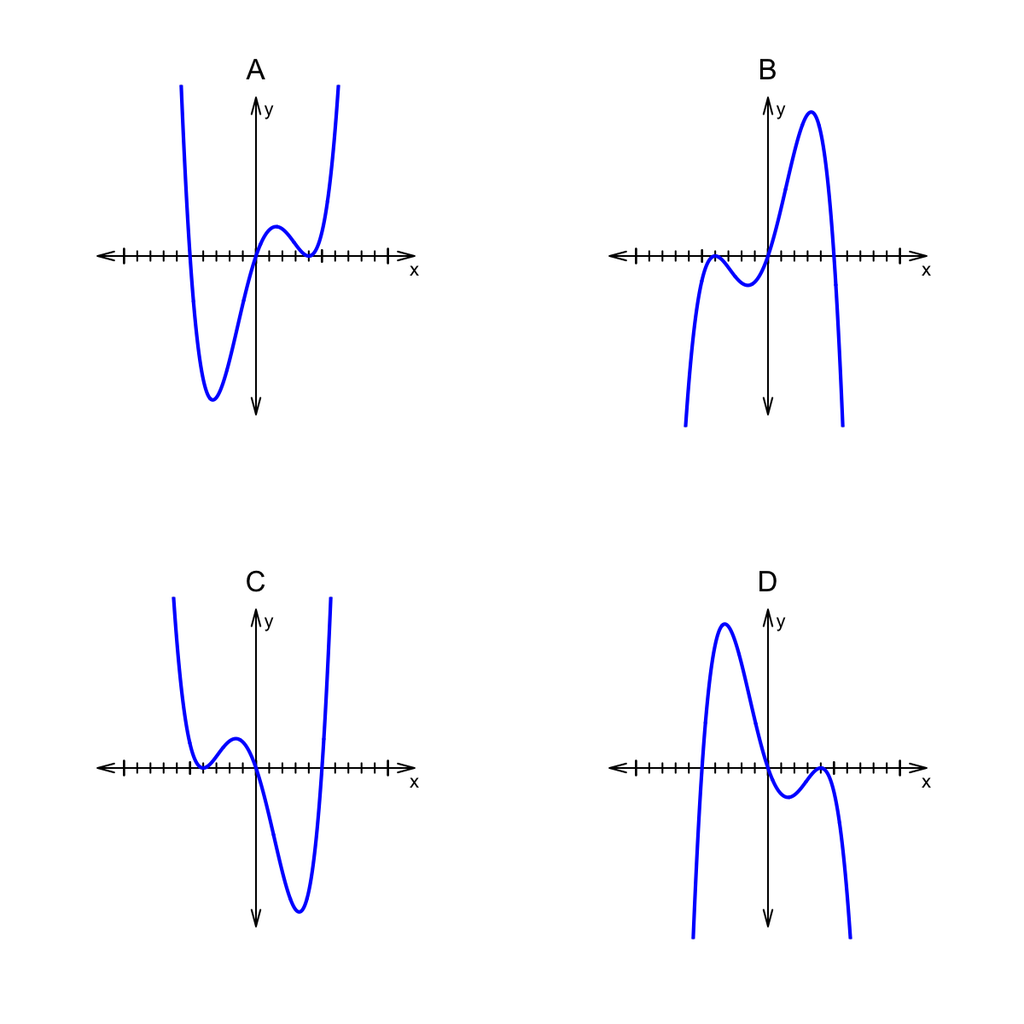

ABCD

First, consider the end behavior. If you expanded the polynomial into standard form, the highest-degree term would be $-x^{4}$.

$$p(x)~=~-x^{4}+\ldots$$

The highest degree term has a negative coefficient and an even degree, so the end behavior is **"down,down"**. Or, more formally, $\lim\limits_{x\to-\infty} p(x) ~=~ -\infty$ and $\lim\limits_{x\to\infty} p(x) ~=~ -\infty$.

Next, we consider the roots. From the factored form, $p(x)~=~-(x+4)^{2}\cdot x\cdot (x-5)$, it is easy to see (see [zero-product property](https://en.wikipedia.org/wiki/Zero-product_property)) that $x=-4$ or $x=0$ or $x=5$ makes the polynomial output 0.

$$p(-4)~=~-(-4+4)^{2}\cdot -4\cdot
(-4-5)~=~0$$
$$p(0)~=~-(0+4)^{2}\cdot
0\cdot (0-5)~=~0$$
$$p(5)~=~-(5+4)^{2}\cdot 5\cdot
(5-5)~=~0$$

We predict that at $x=-4$ there is a double root (multiplicity of 2) because the corresponding factor is squared. Graphically, we expect the curve to "bounce" off the $x$ axis at $x=-4$. At the other roots, we expect the curve to cut through the $x$ axis.

Anyway, based on this analysis, we can produce a [sign](https://en.wikipedia.org/wiki/Sign_function) graph of the polynomial.

| $x$ interval or value | sign analysis of $p(x)~=~-(x+4)^{2}\cdot x\cdot (x-5)$ | sign |
| --- | --- | --- |
| $(-\infty,-4)$ | $-(\mathrm{neg})^{2}\cdot (\mathrm{neg})\cdot (\mathrm{neg})$ | $-1$ |
| $-4$ | $-(\mathrm{zero})^{2}\cdot (\mathrm{neg})\cdot (\mathrm{neg})$ | $0$ |
| $(-4,0)$ | $-(\mathrm{pos})^{2}\cdot (\mathrm{neg})\cdot (\mathrm{neg})$ | $-1$ |
| $0$ | $-(\mathrm{pos})^{2}\cdot (\mathrm{zero})\cdot (\mathrm{neg})$ | $0$ |
| $(0,5)$ | $-(\mathrm{pos})^{2}\cdot (\mathrm{pos})\cdot (\mathrm{neg})$ | $1$ |
| $5$ | $-(\mathrm{pos})^{2}\cdot (\mathrm{pos})\cdot (\mathrm{zero})$ | $0$ |
| $(5,\infty)$ | $-(\mathrm{pos})^{2}\cdot (\mathrm{pos})\cdot (\mathrm{pos})$ | $-1$ |

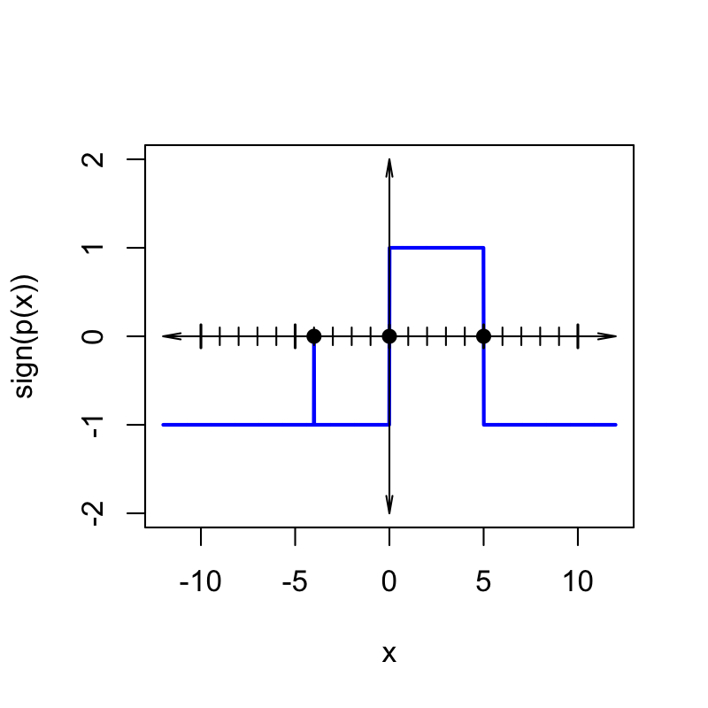

And only one option matches.

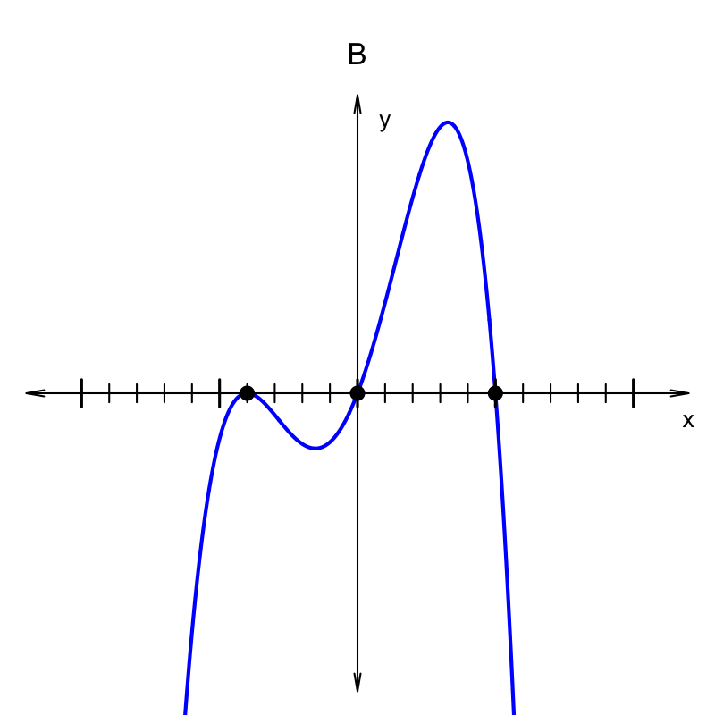

A polynomial, $p(x)$, is given in factored form.
$$p(x)~=~(x+2)^{2}\cdot
(x-4)\cdot (x-8)$$

Which of the following graphs matches $y=p(x)$?

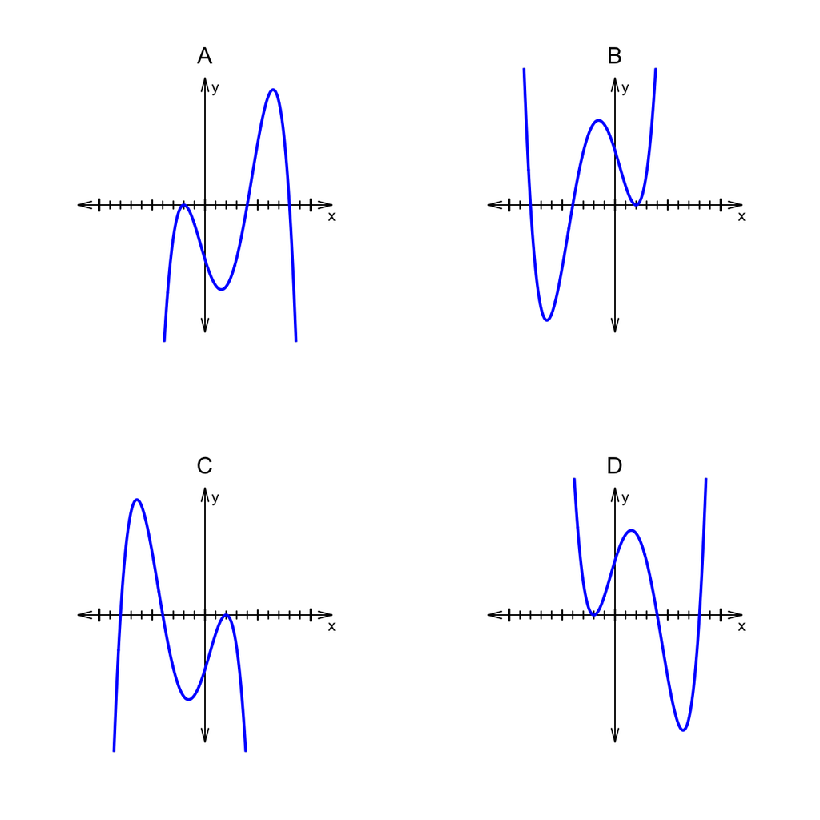

ABCD

First, consider the end behavior. If you expanded the polynomial into standard form, the highest-degree term would be $x^{4}$.

$$p(x)~=~x^{4}+\ldots$$

The highest degree term has a positive coefficient and an even degree, so the end behavior is **"up,up"**. Or, more formally, $\lim\limits_{x\to-\infty} p(x) ~=~ \infty$ and $\lim\limits_{x\to\infty} p(x) ~=~ \infty$.

Next, we consider the roots. From the factored form, $p(x)~=~(x+2)^{2}\cdot (x-4)\cdot (x-8)$, it is easy to see (see [zero-product property](https://en.wikipedia.org/wiki/Zero-product_property)) that $x=-2$ or $x=4$ or $x=8$ makes the polynomial output 0.

$$p(-2)~=~(-2+2)^{2}\cdot (-2-4)\cdot
(-2-8)~=~0$$
$$p(4)~=~(4+2)^{2}\cdot
(4-4)\cdot (4-8)~=~0$$
$$p(8)~=~(8+2)^{2}\cdot (8-4)\cdot
(8-8)~=~0$$

We predict that at $x=-2$ there is a double root (multiplicity of 2) because the corresponding factor is squared. Graphically, we expect the curve to "bounce" off the $x$ axis at $x=-2$. At the other roots, we expect the curve to cut through the $x$ axis.

Anyway, based on this analysis, we can produce a [sign](https://en.wikipedia.org/wiki/Sign_function) graph of the polynomial.

| $x$ interval or value | sign analysis of $p(x)~=~(x+2)^{2}\cdot (x-4)\cdot (x-8)$ | sign |
| --- | --- | --- |
| $(-\infty,-2)$ | $(\mathrm{neg})^{2}\cdot (\mathrm{neg})\cdot (\mathrm{neg})$ | $1$ |
| $-2$ | $(\mathrm{zero})^{2}\cdot (\mathrm{neg})\cdot (\mathrm{neg})$ | $0$ |
| $(-2,4)$ | $(\mathrm{pos})^{2}\cdot (\mathrm{neg})\cdot (\mathrm{neg})$ | $1$ |
| $4$ | $(\mathrm{pos})^{2}\cdot (\mathrm{zero})\cdot (\mathrm{neg})$ | $0$ |
| $(4,8)$ | $(\mathrm{pos})^{2}\cdot (\mathrm{pos})\cdot (\mathrm{neg})$ | $-1$ |
| $8$ | $(\mathrm{pos})^{2}\cdot (\mathrm{pos})\cdot (\mathrm{zero})$ | $0$ |
| $(8,\infty)$ | $(\mathrm{pos})^{2}\cdot (\mathrm{pos})\cdot (\mathrm{pos})$ | $1$ |

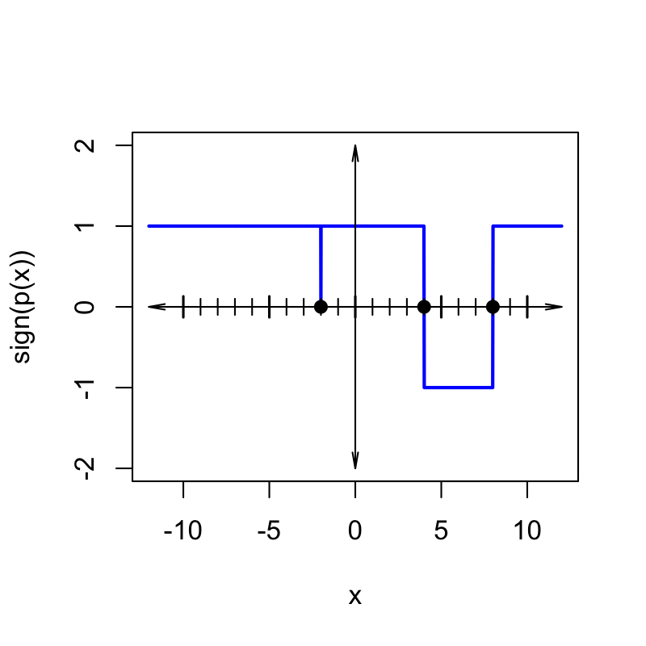

And only one option matches.

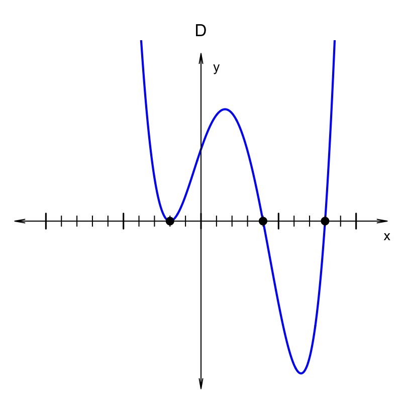

A polynomial, $p(x)$, is given in factored form.
$$p(x)~=~-(x+6)\cdot
(x-4)^{2}\cdot (x-9)$$

Which of the following graphs matches $y=p(x)$?

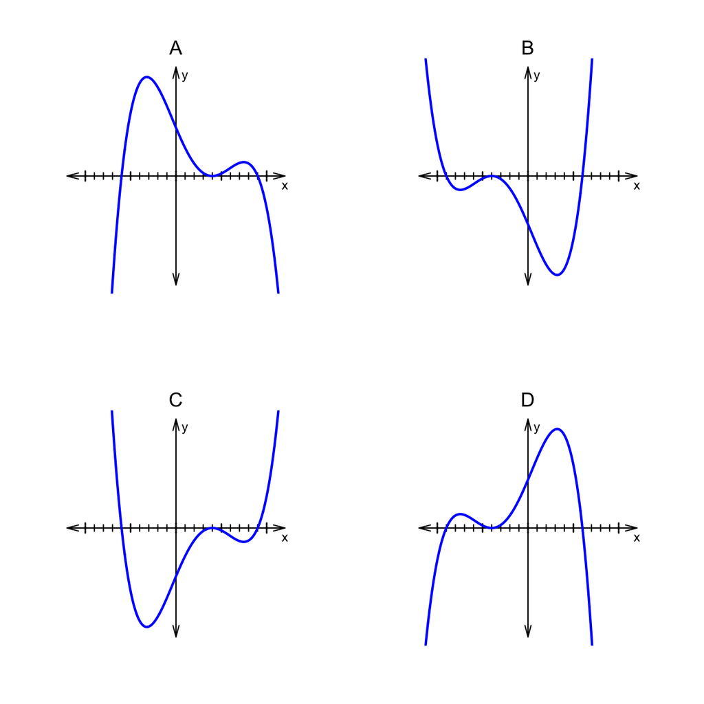

ABCD

First, consider the end behavior. If you expanded the polynomial into standard form, the highest-degree term would be $-x^{4}$.

$$p(x)~=~-x^{4}+\ldots$$

The highest degree term has a negative coefficient and an even degree, so the end behavior is **"down,down"**. Or, more formally, $\lim\limits_{x\to-\infty} p(x) ~=~ -\infty$ and $\lim\limits_{x\to\infty} p(x) ~=~ -\infty$.

Next, we consider the roots. From the factored form, $p(x)~=~-(x+6)\cdot (x-4)^{2}\cdot (x-9)$, it is easy to see (see [zero-product property](https://en.wikipedia.org/wiki/Zero-product_property)) that $x=-6$ or $x=4$ or $x=9$ makes the polynomial output 0.

$$p(-6)~=~-(-6+6)\cdot (-6-4)^{2}\cdot
(-6-9)~=~0$$
$$p(4)~=~-(4+6)\cdot
(4-4)^{2}\cdot (4-9)~=~0$$
$$p(9)~=~-(9+6)\cdot (9-4)^{2}\cdot
(9-9)~=~0$$

We predict that at $x=4$ there is a double root (multiplicity of 2) because the corresponding factor is squared. Graphically, we expect the curve to "bounce" off the $x$ axis at $x=4$. At the other roots, we expect the curve to cut through the $x$ axis.

Anyway, based on this analysis, we can produce a [sign](https://en.wikipedia.org/wiki/Sign_function) graph of the polynomial.

| $x$ interval or value | sign analysis of $p(x)~=~-(x+6)\cdot (x-4)^{2}\cdot (x-9)$ | sign |
| --- | --- | --- |
| $(-\infty,-6)$ | $-(\mathrm{neg})\cdot (\mathrm{neg})^{2}\cdot (\mathrm{neg})$ | $-1$ |
| $-6$ | $-(\mathrm{zero})\cdot (\mathrm{neg})^{2}\cdot (\mathrm{neg})$ | $0$ |
| $(-6,4)$ | $-(\mathrm{pos})\cdot (\mathrm{neg})^{2}\cdot (\mathrm{neg})$ | $1$ |
| $4$ | $-(\mathrm{pos})\cdot (\mathrm{zero})^{2}\cdot (\mathrm{neg})$ | $0$ |
| $(4,9)$ | $-(\mathrm{pos})\cdot (\mathrm{pos})^{2}\cdot (\mathrm{neg})$ | $1$ |
| $9$ | $-(\mathrm{pos})\cdot (\mathrm{pos})^{2}\cdot (\mathrm{zero})$ | $0$ |
| $(9,\infty)$ | $-(\mathrm{pos})\cdot (\mathrm{pos})^{2}\cdot (\mathrm{pos})$ | $-1$ |

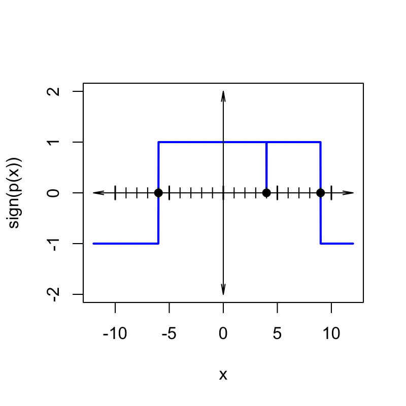

And only one option matches.

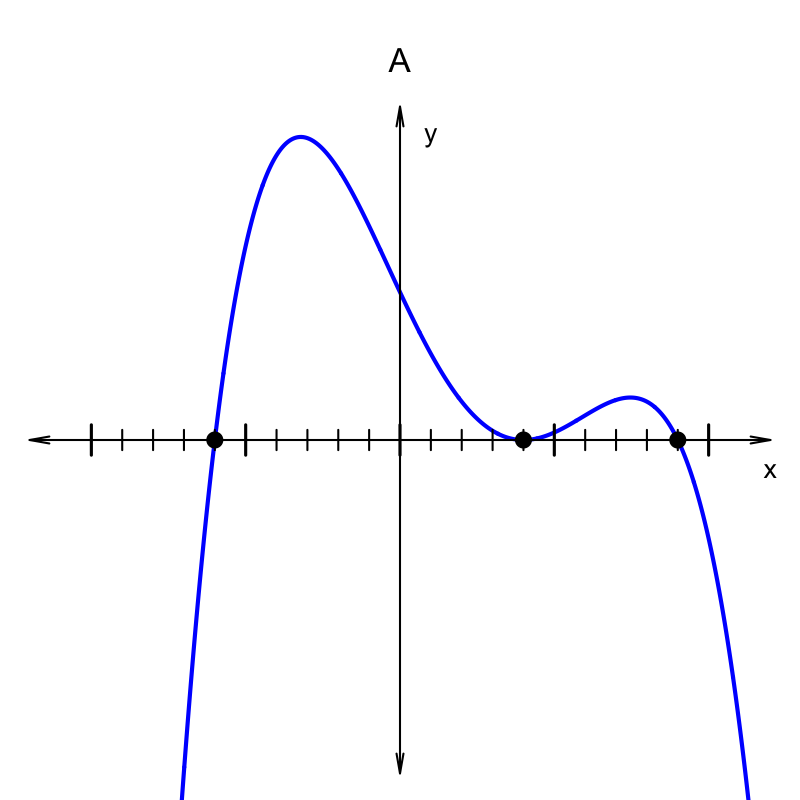

A polynomial, $p(x)$, is given in factored form.
$$p(x)~=~-(x-4)\cdot
(x-9)^{2}$$

Which of the following graphs matches $y=p(x)$?

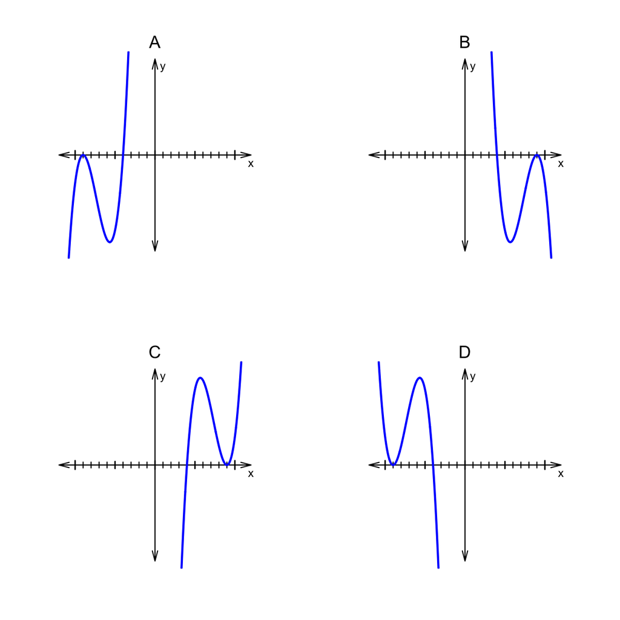

ABCD

First, consider the end behavior. If you expanded the polynomial into standard form, the highest-degree term would be $-x^{3}$.

$$p(x)~=~-x^{3}+\ldots$$

The highest degree term has a negative coefficient and an odd degree, so the end behavior is **"up,down"**. Or, more formally, $\lim\limits_{x\to-\infty} p(x) ~=~ \infty$ and $\lim\limits_{x\to\infty} p(x) ~=~ -\infty$.

Next, we consider the roots. From the factored form, $p(x)~=~-(x-4)\cdot (x-9)^{2}$, it is easy to see (see [zero-product property](https://en.wikipedia.org/wiki/Zero-product_property)) that $x=4$ or $x=9$ makes the polynomial output 0.

$$p(4)~=~-(4-4)\cdot
(4-9)^{2}~=~0$$
$$p(9)~=~-(9-4)\cdot
(9-9)^{2}~=~0$$

We predict that at $x=9$ there is a double root (multiplicity of 2) because the corresponding factor is squared. Graphically, we expect the curve to "bounce" off the $x$ axis at $x=9$. At the other root, we expect the curve to cut through the $x$ axis.

Anyway, based on this analysis, we can produce a [sign](https://en.wikipedia.org/wiki/Sign_function) graph of the polynomial.

| $x$ interval or value | sign analysis of $p(x)~=~-(x-4)\cdot (x-9)^{2}$ | sign |
| --- | --- | --- |
| $(-\infty,4)$ | $-(\mathrm{neg})\cdot (\mathrm{neg})^{2}$ | $1$ |
| $4$ | $-(\mathrm{zero})\cdot (\mathrm{neg})^{2}$ | $0$ |
| $(4,9)$ | $-(\mathrm{pos})\cdot (\mathrm{neg})^{2}$ | $-1$ |
| $9$ | $-(\mathrm{pos})\cdot (\mathrm{zero})^{2}$ | $0$ |
| $(9,\infty)$ | $-(\mathrm{pos})\cdot (\mathrm{pos})^{2}$ | $-1$ |

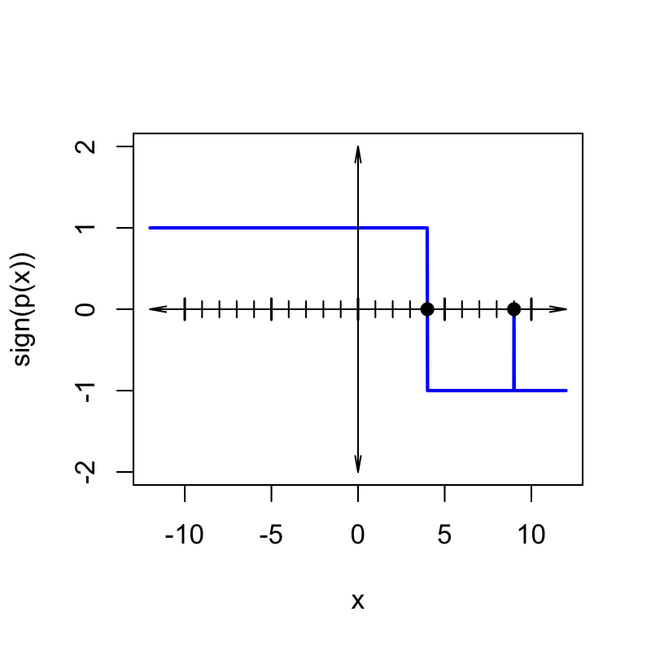

And only one option matches.

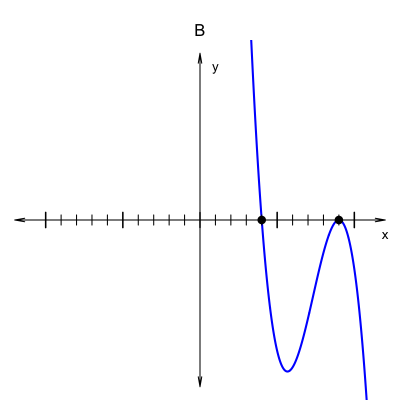

A polynomial, $p(x)$, is given in factored form.
$$p(x)~=~-(x+9)\cdot
(x-6)^{2}\cdot (x-9)$$

Which of the following graphs matches $y=p(x)$?

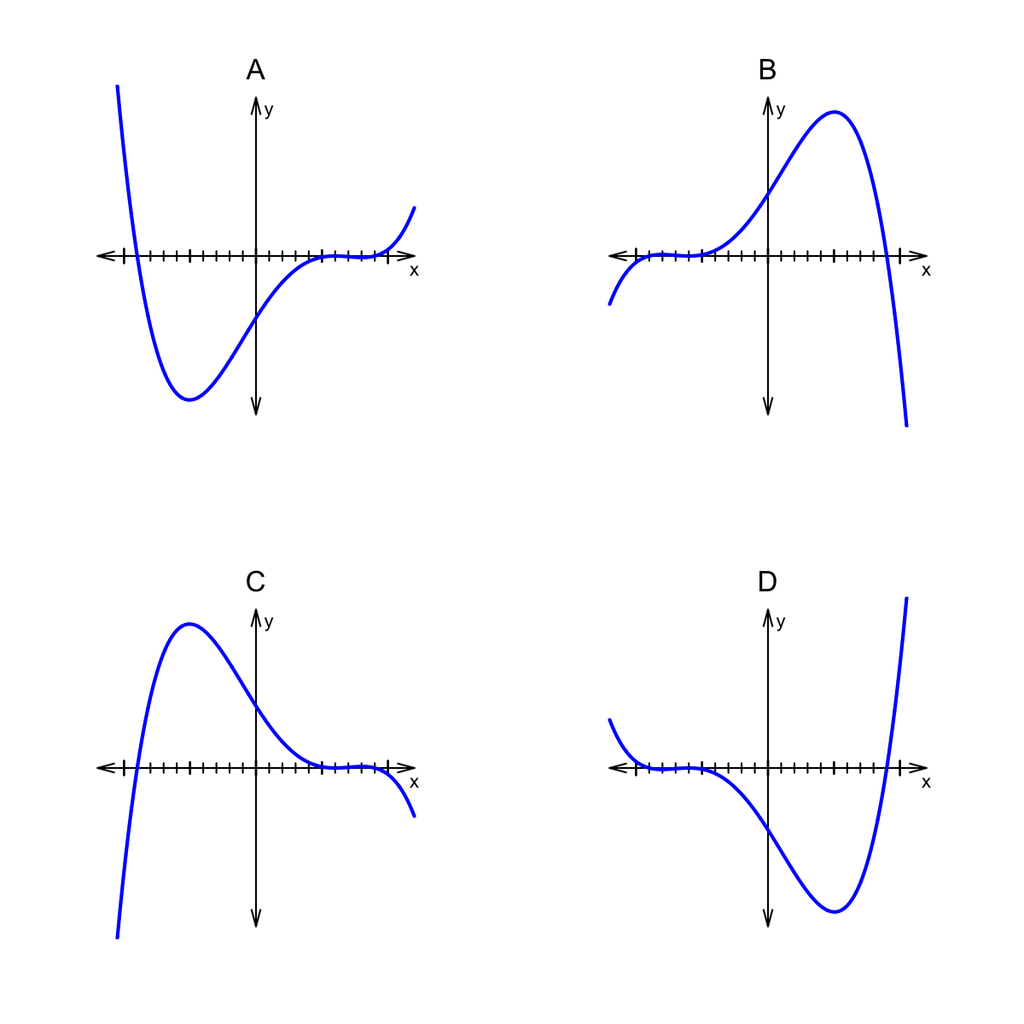

ABCD

First, consider the end behavior. If you expanded the polynomial into standard form, the highest-degree term would be $-x^{4}$.

$$p(x)~=~-x^{4}+\ldots$$

The highest degree term has a negative coefficient and an even degree, so the end behavior is **"down,down"**. Or, more formally, $\lim\limits_{x\to-\infty} p(x) ~=~ -\infty$ and $\lim\limits_{x\to\infty} p(x) ~=~ -\infty$.

Next, we consider the roots. From the factored form, $p(x)~=~-(x+9)\cdot (x-6)^{2}\cdot (x-9)$, it is easy to see (see [zero-product property](https://en.wikipedia.org/wiki/Zero-product_property)) that $x=-9$ or $x=6$ or $x=9$ makes the polynomial output 0.

$$p(-9)~=~-(-9+9)\cdot (-9-6)^{2}\cdot
(-9-9)~=~0$$
$$p(6)~=~-(6+9)\cdot
(6-6)^{2}\cdot (6-9)~=~0$$
$$p(9)~=~-(9+9)\cdot (9-6)^{2}\cdot
(9-9)~=~0$$

We predict that at $x=6$ there is a double root (multiplicity of 2) because the corresponding factor is squared. Graphically, we expect the curve to "bounce" off the $x$ axis at $x=6$. At the other roots, we expect the curve to cut through the $x$ axis.

Anyway, based on this analysis, we can produce a [sign](https://en.wikipedia.org/wiki/Sign_function) graph of the polynomial.

| $x$ interval or value | sign analysis of $p(x)~=~-(x+9)\cdot (x-6)^{2}\cdot (x-9)$ | sign |
| --- | --- | --- |
| $(-\infty,-9)$ | $-(\mathrm{neg})\cdot (\mathrm{neg})^{2}\cdot (\mathrm{neg})$ | $-1$ |
| $-9$ | $-(\mathrm{zero})\cdot (\mathrm{neg})^{2}\cdot (\mathrm{neg})$ | $0$ |
| $(-9,6)$ | $-(\mathrm{pos})\cdot (\mathrm{neg})^{2}\cdot (\mathrm{neg})$ | $1$ |
| $6$ | $-(\mathrm{pos})\cdot (\mathrm{zero})^{2}\cdot (\mathrm{neg})$ | $0$ |
| $(6,9)$ | $-(\mathrm{pos})\cdot (\mathrm{pos})^{2}\cdot (\mathrm{neg})$ | $1$ |
| $9$ | $-(\mathrm{pos})\cdot (\mathrm{pos})^{2}\cdot (\mathrm{zero})$ | $0$ |
| $(9,\infty)$ | $-(\mathrm{pos})\cdot (\mathrm{pos})^{2}\cdot (\mathrm{pos})$ | $-1$ |

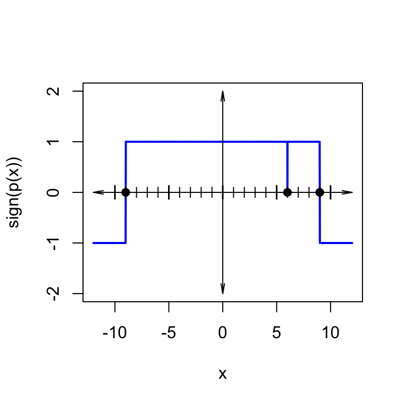

And only one option matches.

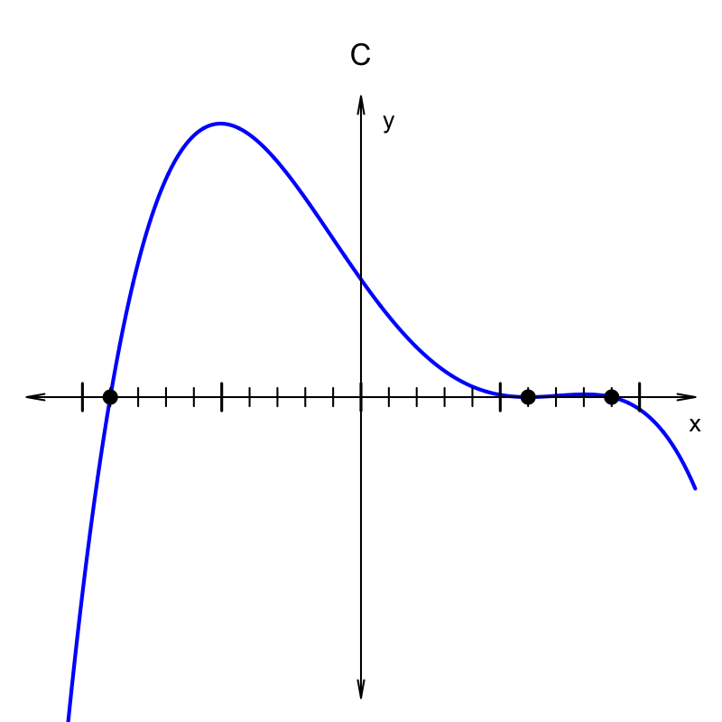

A polynomial, $p(x)$, is given in factored form.
$$p(x)~=~-(x+9)^{2}\cdot
x\cdot (x-6)$$

Which of the following graphs matches $y=p(x)$?

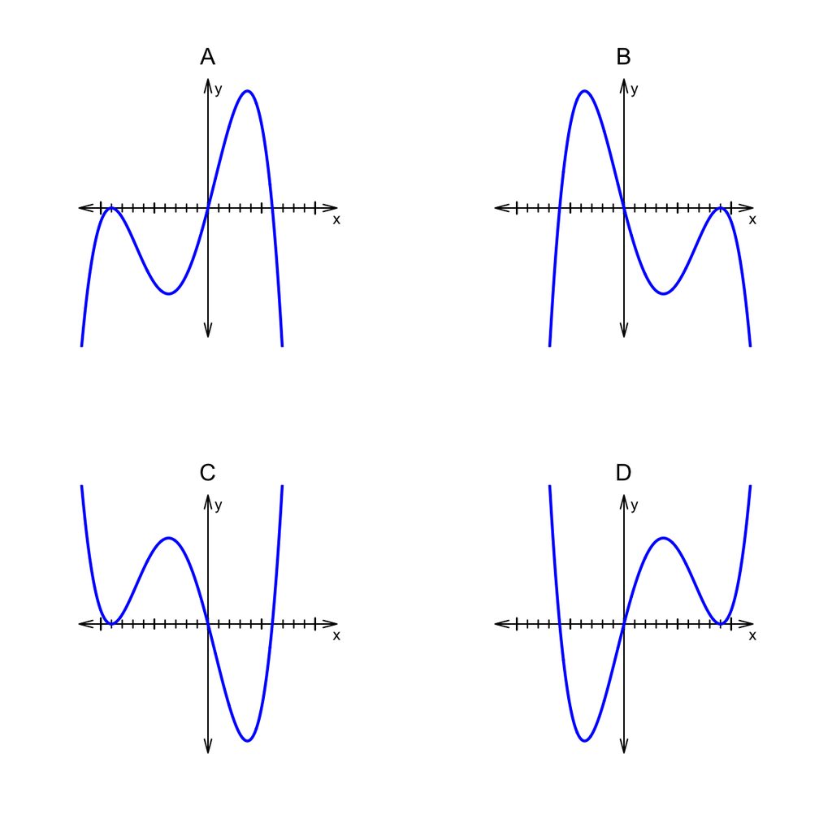

ABCD

First, consider the end behavior. If you expanded the polynomial into standard form, the highest-degree term would be $-x^{4}$.

$$p(x)~=~-x^{4}+\ldots$$

The highest degree term has a negative coefficient and an even degree, so the end behavior is **"down,down"**. Or, more formally, $\lim\limits_{x\to-\infty} p(x) ~=~ -\infty$ and $\lim\limits_{x\to\infty} p(x) ~=~ -\infty$.

Next, we consider the roots. From the factored form, $p(x)~=~-(x+9)^{2}\cdot x\cdot (x-6)$, it is easy to see (see [zero-product property](https://en.wikipedia.org/wiki/Zero-product_property)) that $x=-9$ or $x=0$ or $x=6$ makes the polynomial output 0.

$$p(-9)~=~-(-9+9)^{2}\cdot -9\cdot
(-9-6)~=~0$$
$$p(0)~=~-(0+9)^{2}\cdot
0\cdot (0-6)~=~0$$
$$p(6)~=~-(6+9)^{2}\cdot 6\cdot
(6-6)~=~0$$

We predict that at $x=-9$ there is a double root (multiplicity of 2) because the corresponding factor is squared. Graphically, we expect the curve to "bounce" off the $x$ axis at $x=-9$. At the other roots, we expect the curve to cut through the $x$ axis.

Anyway, based on this analysis, we can produce a [sign](https://en.wikipedia.org/wiki/Sign_function) graph of the polynomial.

| $x$ interval or value | sign analysis of $p(x)~=~-(x+9)^{2}\cdot x\cdot (x-6)$ | sign |
| --- | --- | --- |
| $(-\infty,-9)$ | $-(\mathrm{neg})^{2}\cdot (\mathrm{neg})\cdot (\mathrm{neg})$ | $-1$ |
| $-9$ | $-(\mathrm{zero})^{2}\cdot (\mathrm{neg})\cdot (\mathrm{neg})$ | $0$ |
| $(-9,0)$ | $-(\mathrm{pos})^{2}\cdot (\mathrm{neg})\cdot (\mathrm{neg})$ | $-1$ |
| $0$ | $-(\mathrm{pos})^{2}\cdot (\mathrm{zero})\cdot (\mathrm{neg})$ | $0$ |
| $(0,6)$ | $-(\mathrm{pos})^{2}\cdot (\mathrm{pos})\cdot (\mathrm{neg})$ | $1$ |
| $6$ | $-(\mathrm{pos})^{2}\cdot (\mathrm{pos})\cdot (\mathrm{zero})$ | $0$ |
| $(6,\infty)$ | $-(\mathrm{pos})^{2}\cdot (\mathrm{pos})\cdot (\mathrm{pos})$ | $-1$ |

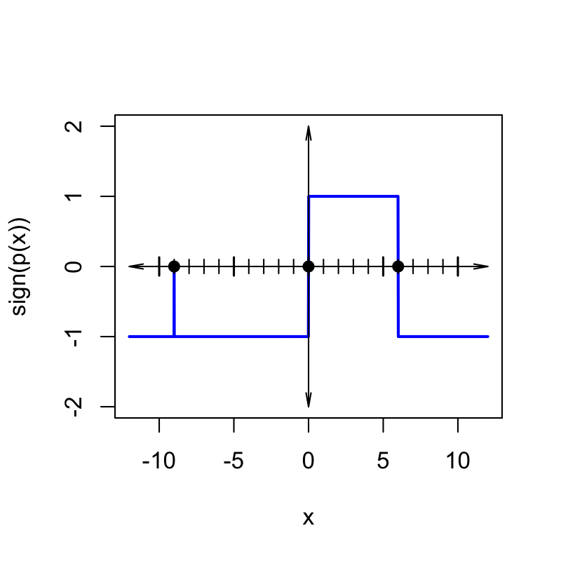

And only one option matches.

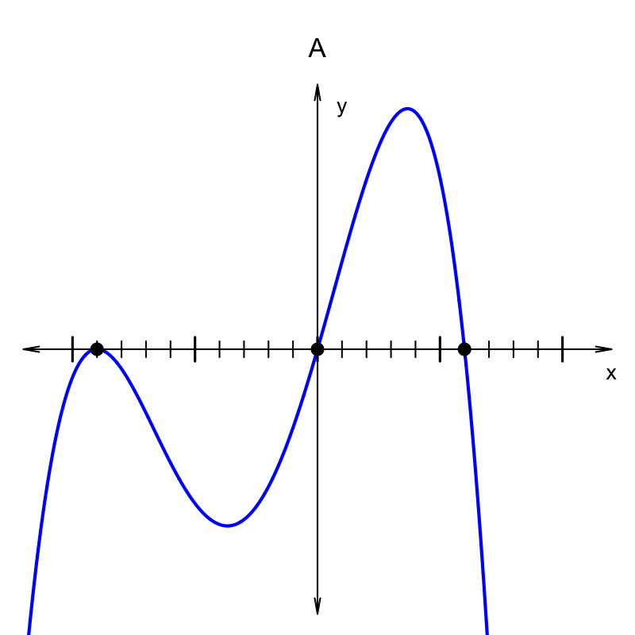

A polynomial, $p(x)$, is given in factored form.
$$p(x)~=~-(x+9)^{2}\cdot
(x+1)$$

Which of the following graphs matches $y=p(x)$?

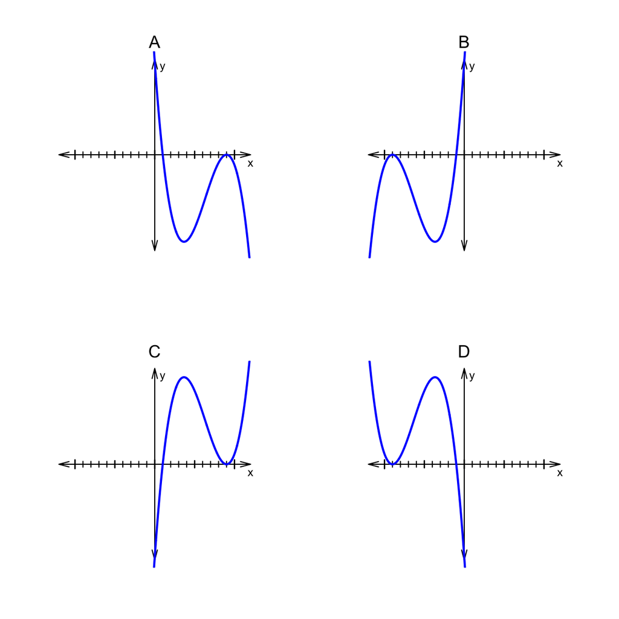

ABCD

First, consider the end behavior. If you expanded the polynomial into standard form, the highest-degree term would be $-x^{3}$.

$$p(x)~=~-x^{3}+\ldots$$

The highest degree term has a negative coefficient and an odd degree, so the end behavior is **"up,down"**. Or, more formally, $\lim\limits_{x\to-\infty} p(x) ~=~ \infty$ and $\lim\limits_{x\to\infty} p(x) ~=~ -\infty$.

Next, we consider the roots. From the factored form, $p(x)~=~-(x+9)^{2}\cdot (x+1)$, it is easy to see (see [zero-product property](https://en.wikipedia.org/wiki/Zero-product_property)) that $x=-9$ or $x=-1$ makes the polynomial output 0.

$$p(-9)~=~-(-9+9)^{2}\cdot
(-9+1)~=~0$$
$$p(-1)~=~-(-1+9)^{2}\cdot (-1+1)~=~0$$

We predict that at $x=-9$ there is a double root (multiplicity of 2) because the corresponding factor is squared. Graphically, we expect the curve to "bounce" off the $x$ axis at $x=-9$. At the other root, we expect the curve to cut through the $x$ axis.

Anyway, based on this analysis, we can produce a [sign](https://en.wikipedia.org/wiki/Sign_function) graph of the polynomial.

| $x$ interval or value | sign analysis of $p(x)~=~-(x+9)^{2}\cdot (x+1)$ | sign |
| --- | --- | --- |
| $(-\infty,-9)$ | $-(\mathrm{neg})^{2}\cdot (\mathrm{neg})$ | $1$ |
| $-9$ | $-(\mathrm{zero})^{2}\cdot (\mathrm{neg})$ | $0$ |
| $(-9,-1)$ | $-(\mathrm{pos})^{2}\cdot (\mathrm{neg})$ | $1$ |
| $-1$ | $-(\mathrm{pos})^{2}\cdot (\mathrm{zero})$ | $0$ |
| $(-1,\infty)$ | $-(\mathrm{pos})^{2}\cdot (\mathrm{pos})$ | $-1$ |

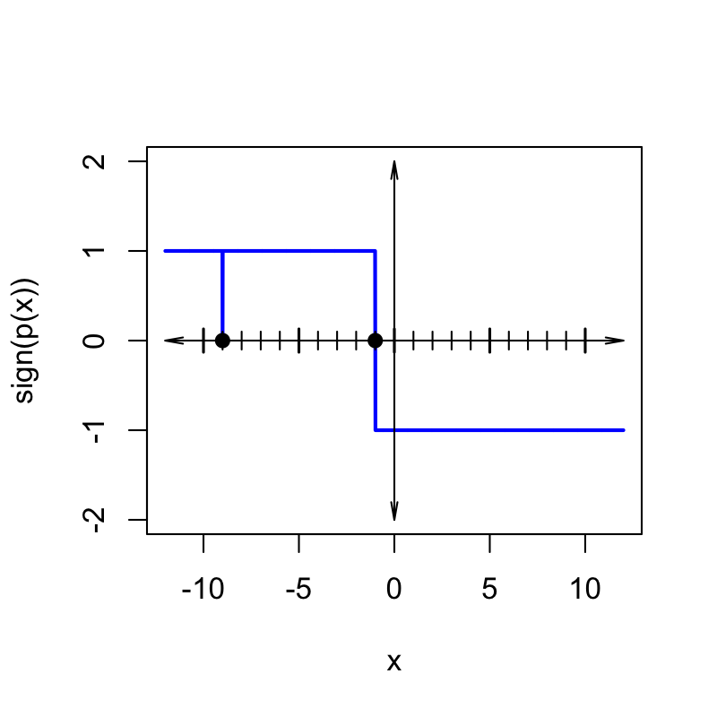

And only one option matches.

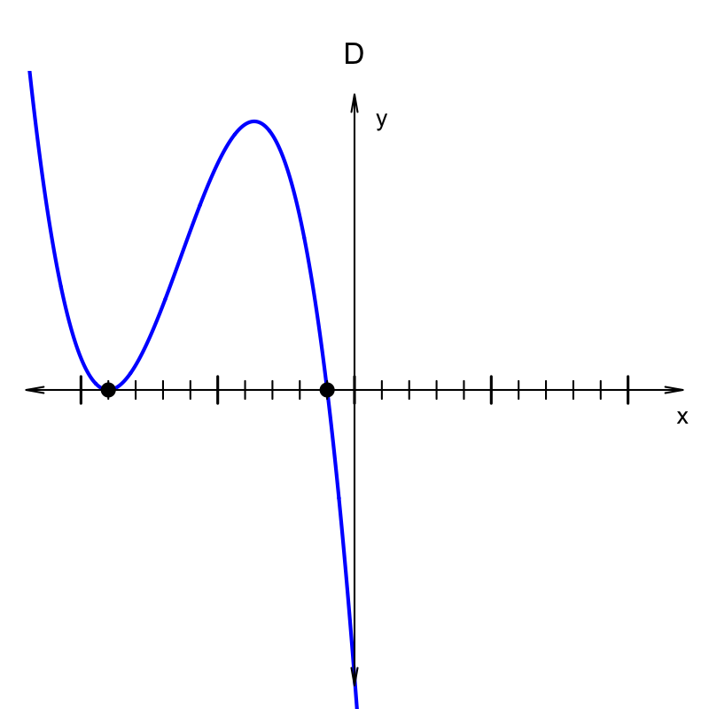

A polynomial, $p(x)$, is given in factored form.
$$p(x)~=~-(x+9)\cdot
x^{2}\cdot (x-5)$$

Which of the following graphs matches $y=p(x)$?

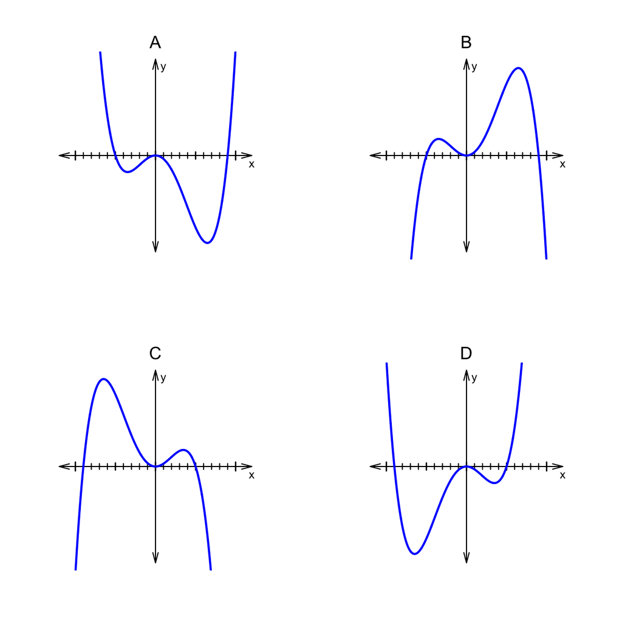

ABCD

First, consider the end behavior. If you expanded the polynomial into standard form, the highest-degree term would be $-x^{4}$.

$$p(x)~=~-x^{4}+\ldots$$

The highest degree term has a negative coefficient and an even degree, so the end behavior is **"down,down"**. Or, more formally, $\lim\limits_{x\to-\infty} p(x) ~=~ -\infty$ and $\lim\limits_{x\to\infty} p(x) ~=~ -\infty$.

Next, we consider the roots. From the factored form, $p(x)~=~-(x+9)\cdot x^{2}\cdot (x-5)$, it is easy to see (see [zero-product property](https://en.wikipedia.org/wiki/Zero-product_property)) that $x=-9$ or $x=0$ or $x=5$ makes the polynomial output 0.

$$p(-9)~=~-(-9+9)\cdot -9^{2}\cdot
(-9-5)~=~0$$
$$p(0)~=~-(0+9)\cdot
0^{2}\cdot (0-5)~=~0$$
$$p(5)~=~-(5+9)\cdot 5^{2}\cdot
(5-5)~=~0$$

We predict that at $x=0$ there is a double root (multiplicity of 2) because the corresponding factor is squared. Graphically, we expect the curve to "bounce" off the $x$ axis at $x=0$. At the other roots, we expect the curve to cut through the $x$ axis.

Anyway, based on this analysis, we can produce a [sign](https://en.wikipedia.org/wiki/Sign_function) graph of the polynomial.

| $x$ interval or value | sign analysis of $p(x)~=~-(x+9)\cdot x^{2}\cdot (x-5)$ | sign |
| --- | --- | --- |
| $(-\infty,-9)$ | $-(\mathrm{neg})\cdot (\mathrm{neg})^{2}\cdot (\mathrm{neg})$ | $-1$ |
| $-9$ | $-(\mathrm{zero})\cdot (\mathrm{neg})^{2}\cdot (\mathrm{neg})$ | $0$ |
| $(-9,0)$ | $-(\mathrm{pos})\cdot (\mathrm{neg})^{2}\cdot (\mathrm{neg})$ | $1$ |
| $0$ | $-(\mathrm{pos})\cdot (\mathrm{zero})^{2}\cdot (\mathrm{neg})$ | $0$ |
| $(0,5)$ | $-(\mathrm{pos})\cdot (\mathrm{pos})^{2}\cdot (\mathrm{neg})$ | $1$ |
| $5$ | $-(\mathrm{pos})\cdot (\mathrm{pos})^{2}\cdot (\mathrm{zero})$ | $0$ |
| $(5,\infty)$ | $-(\mathrm{pos})\cdot (\mathrm{pos})^{2}\cdot (\mathrm{pos})$ | $-1$ |

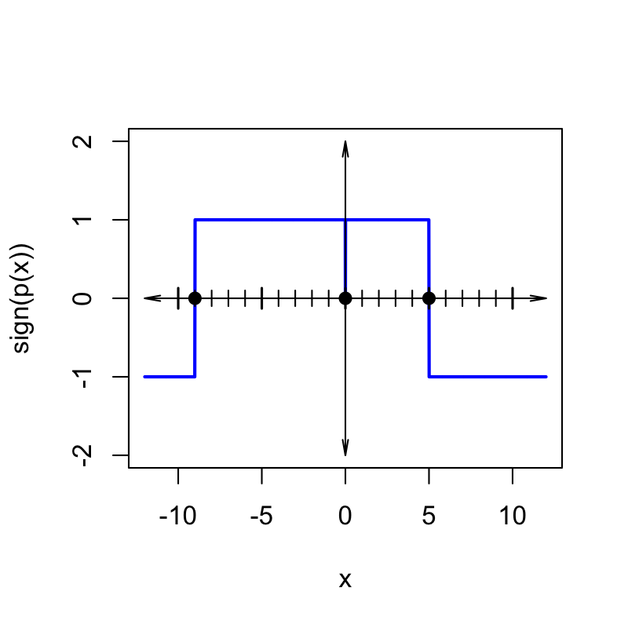

And only one option matches.

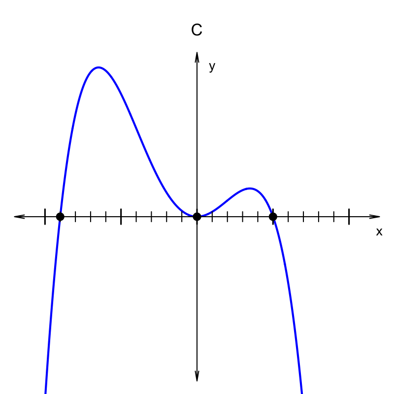

A polynomial, $p(x)$, is given in factored form.
$$p(x)~=~(x+9)^{2}\cdot
(x+2)\cdot (x-6)$$

Which of the following graphs matches $y=p(x)$?

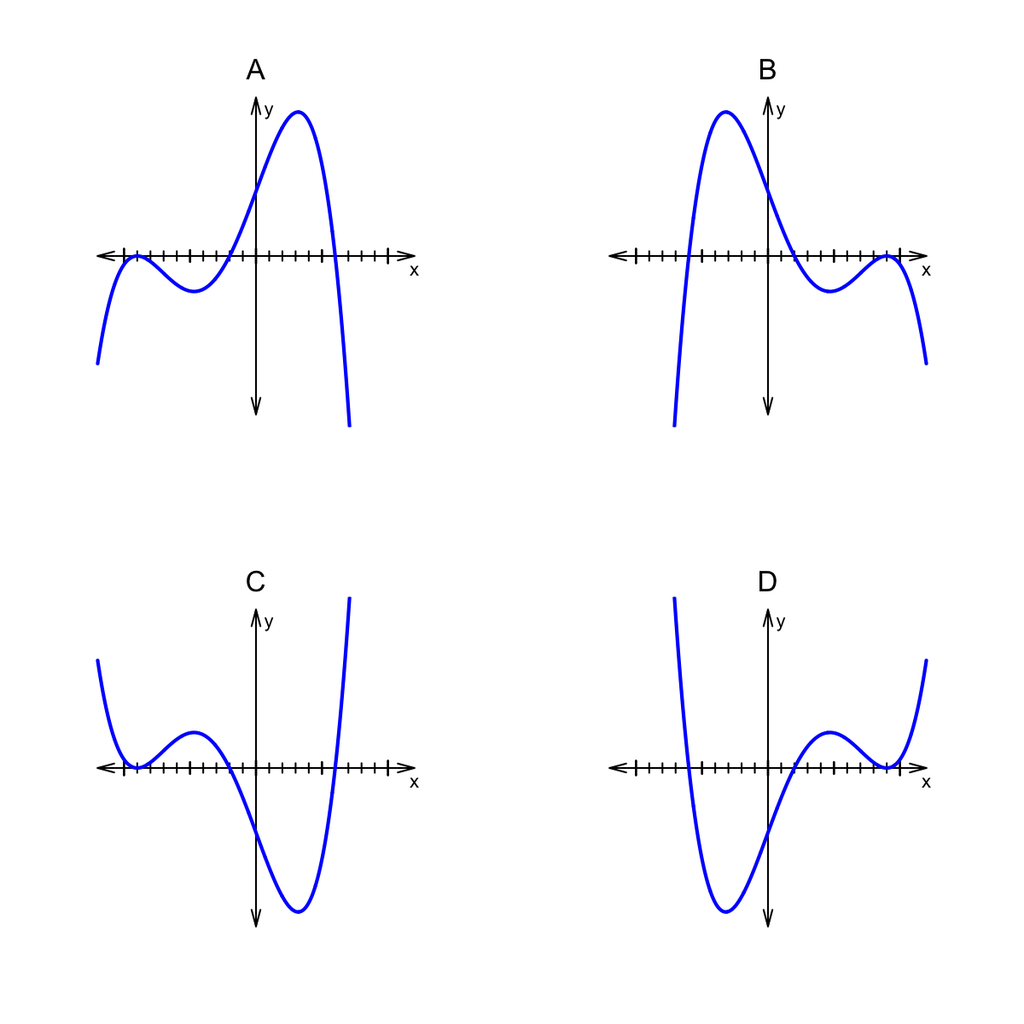

ABCD

First, consider the end behavior. If you expanded the polynomial into standard form, the highest-degree term would be $x^{4}$.

$$p(x)~=~x^{4}+\ldots$$

The highest degree term has a positive coefficient and an even degree, so the end behavior is **"up,up"**. Or, more formally, $\lim\limits_{x\to-\infty} p(x) ~=~ \infty$ and $\lim\limits_{x\to\infty} p(x) ~=~ \infty$.

Next, we consider the roots. From the factored form, $p(x)~=~(x+9)^{2}\cdot (x+2)\cdot (x-6)$, it is easy to see (see [zero-product property](https://en.wikipedia.org/wiki/Zero-product_property)) that $x=-9$ or $x=-2$ or $x=6$ makes the polynomial output 0.

$$p(-9)~=~(-9+9)^{2}\cdot (-9+2)\cdot
(-9-6)~=~0$$
$$p(-2)~=~(-2+9)^{2}\cdot
(-2+2)\cdot (-2-6)~=~0$$
$$p(6)~=~(6+9)^{2}\cdot (6+2)\cdot
(6-6)~=~0$$

We predict that at $x=-9$ there is a double root (multiplicity of 2) because the corresponding factor is squared. Graphically, we expect the curve to "bounce" off the $x$ axis at $x=-9$. At the other roots, we expect the curve to cut through the $x$ axis.

Anyway, based on this analysis, we can produce a [sign](https://en.wikipedia.org/wiki/Sign_function) graph of the polynomial.

| $x$ interval or value | sign analysis of $p(x)~=~(x+9)^{2}\cdot (x+2)\cdot (x-6)$ | sign |
| --- | --- | --- |
| $(-\infty,-9)$ | $(\mathrm{neg})^{2}\cdot (\mathrm{neg})\cdot (\mathrm{neg})$ | $1$ |
| $-9$ | $(\mathrm{zero})^{2}\cdot (\mathrm{neg})\cdot (\mathrm{neg})$ | $0$ |
| $(-9,-2)$ | $(\mathrm{pos})^{2}\cdot (\mathrm{neg})\cdot (\mathrm{neg})$ | $1$ |
| $-2$ | $(\mathrm{pos})^{2}\cdot (\mathrm{zero})\cdot (\mathrm{neg})$ | $0$ |
| $(-2,6)$ | $(\mathrm{pos})^{2}\cdot (\mathrm{pos})\cdot (\mathrm{neg})$ | $-1$ |
| $6$ | $(\mathrm{pos})^{2}\cdot (\mathrm{pos})\cdot (\mathrm{zero})$ | $0$ |
| $(6,\infty)$ | $(\mathrm{pos})^{2}\cdot (\mathrm{pos})\cdot (\mathrm{pos})$ | $1$ |

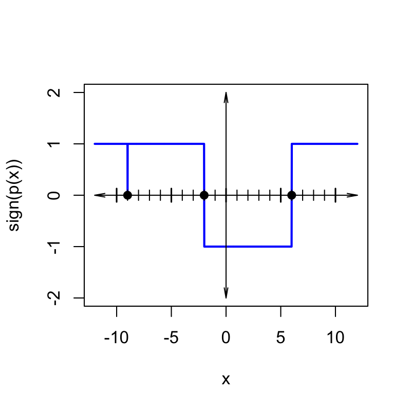

And only one option matches.

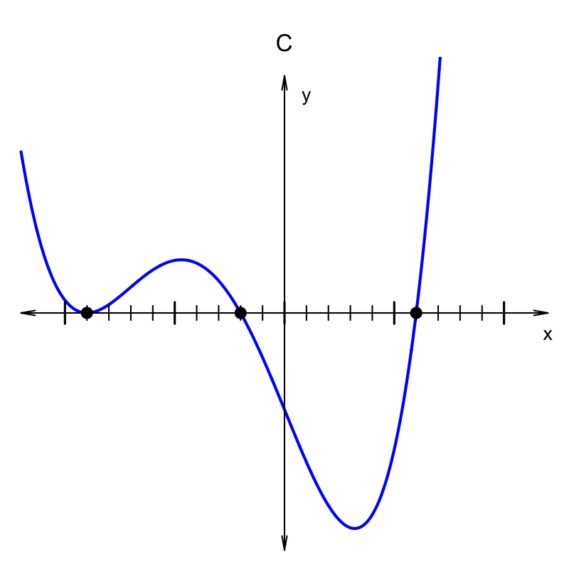

A polynomial, $p(x)$, is given in factored form.
$$p(x)~=~(x+5)^{2}\cdot x\cdot
(x-4)$$

Which of the following graphs matches $y=p(x)$?

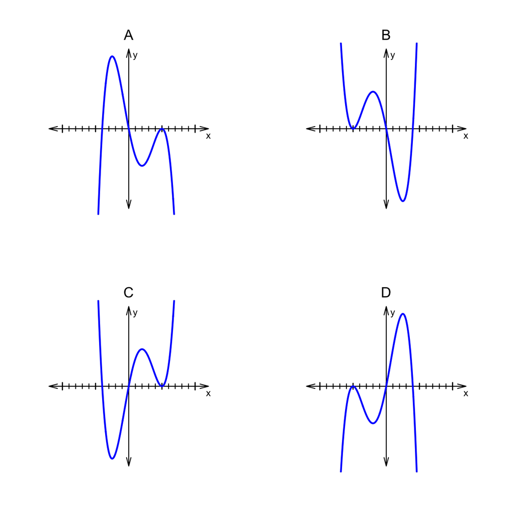

ABCD

First, consider the end behavior. If you expanded the polynomial into standard form, the highest-degree term would be $x^{4}$.

$$p(x)~=~x^{4}+\ldots$$

The highest degree term has a positive coefficient and an even degree, so the end behavior is **"up,up"**. Or, more formally, $\lim\limits_{x\to-\infty} p(x) ~=~ \infty$ and $\lim\limits_{x\to\infty} p(x) ~=~ \infty$.

Next, we consider the roots. From the factored form, $p(x)~=~(x+5)^{2}\cdot x\cdot (x-4)$, it is easy to see (see [zero-product property](https://en.wikipedia.org/wiki/Zero-product_property)) that $x=-5$ or $x=0$ or $x=4$ makes the polynomial output 0.

$$p(-5)~=~(-5+5)^{2}\cdot -5\cdot
(-5-4)~=~0$$
$$p(0)~=~(0+5)^{2}\cdot
0\cdot (0-4)~=~0$$
$$p(4)~=~(4+5)^{2}\cdot 4\cdot
(4-4)~=~0$$

We predict that at $x=-5$ there is a double root (multiplicity of 2) because the corresponding factor is squared. Graphically, we expect the curve to "bounce" off the $x$ axis at $x=-5$. At the other roots, we expect the curve to cut through the $x$ axis.

Anyway, based on this analysis, we can produce a [sign](https://en.wikipedia.org/wiki/Sign_function) graph of the polynomial.

| $x$ interval or value | sign analysis of $p(x)~=~(x+5)^{2}\cdot x\cdot (x-4)$ | sign |
| --- | --- | --- |
| $(-\infty,-5)$ | $(\mathrm{neg})^{2}\cdot (\mathrm{neg})\cdot (\mathrm{neg})$ | $1$ |
| $-5$ | $(\mathrm{zero})^{2}\cdot (\mathrm{neg})\cdot (\mathrm{neg})$ | $0$ |
| $(-5,0)$ | $(\mathrm{pos})^{2}\cdot (\mathrm{neg})\cdot (\mathrm{neg})$ | $1$ |
| $0$ | $(\mathrm{pos})^{2}\cdot (\mathrm{zero})\cdot (\mathrm{neg})$ | $0$ |
| $(0,4)$ | $(\mathrm{pos})^{2}\cdot (\mathrm{pos})\cdot (\mathrm{neg})$ | $-1$ |
| $4$ | $(\mathrm{pos})^{2}\cdot (\mathrm{pos})\cdot (\mathrm{zero})$ | $0$ |
| $(4,\infty)$ | $(\mathrm{pos})^{2}\cdot (\mathrm{pos})\cdot (\mathrm{pos})$ | $1$ |

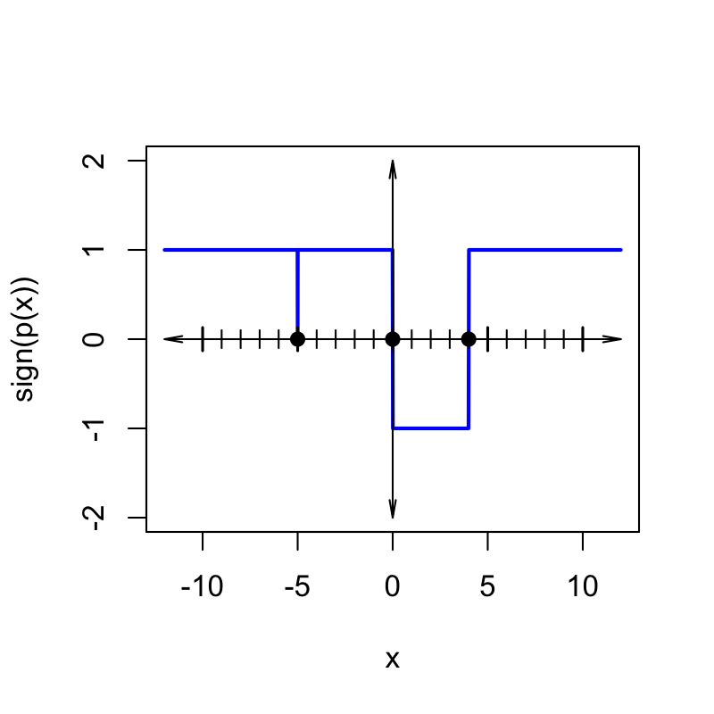

And only one option matches.

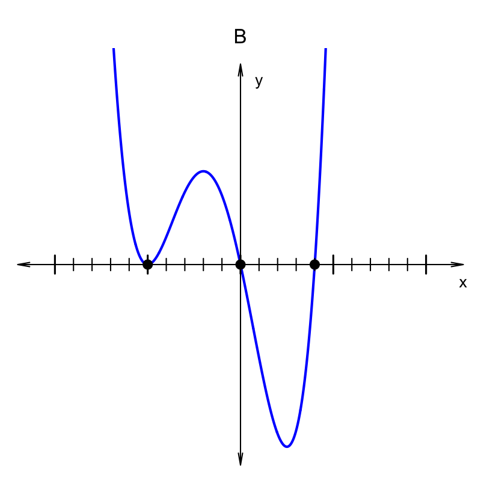

### Graph 1

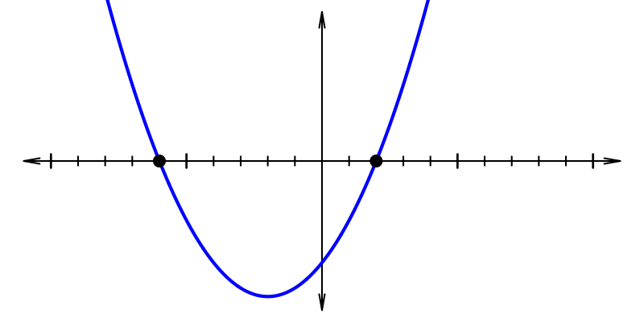

Which function matches Graph 1?

- $A(x)~=~-(x-2)(x-6)^{2}$
- $B(x)~=~(x-2)(x+6)$
- $C(x)~=~(x+2)(x-6)$
- $D(x)~=~(x+2)(x+6)$

### Graph 2

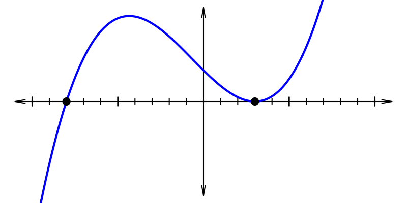

Which function matches Graph 2?

- $A(x)~=~(x-3)(x-8)$
- $B(x)~=~-(x-3)^{2}(x-8)^{2}$
- $C(x)~=~(x-3)^{2}(x+8)$
- $D(x)~=~-(x+3)^{2}(x-8)$

### Graph 3

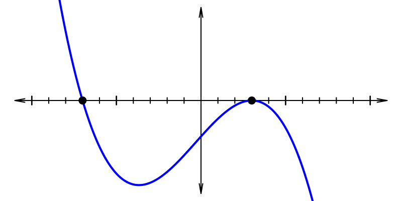

Which function matches Graph 3?

- $A(x)~=~-(x-3)^{2}(x+7)$
- $B(x)~=~(x-3)^{2}(x+7)^{2}$
- $C(x)~=~-(x+3)^{2}(x-7)$
- $D(x)~=~(x+3)^{2}(x-7)^{2}$
- Graph 1 is $B(x)~=~(x-2)(x+6)$
- Graph 2 is $C(x)~=~(x-3)^{2}(x+8)$
- Graph 3 is $A(x)~=~-(x-3)^{2}(x+7)$

Remember, each factor is $(x-r)$ where $r$ is the root. If the factor is squared, we expect a bounce. Lastly, make sure to pay attention to the sign in front, which will dictate the end behavior.

### Graph 1

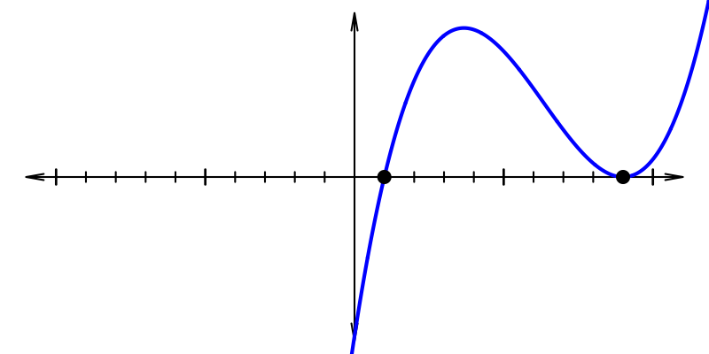

Which function matches Graph 1?

- $A(x)~=~(x-1)(x-9)^{2}$
- $B(x)~=~(x-1)(x+9)^{2}$
- $C(x)~=~(x-1)^{2}(x+9)$
- $D(x)~=~-(x+1)(x+9)^{2}$

### Graph 3

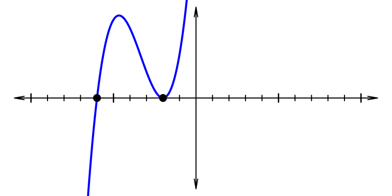

Which function matches Graph 3?

- $A(x)~=~-(x-2)^{2}(x+6)$
- $B(x)~=~-(x+2)^{2}(x-6)^{2}$
- $C(x)~=~(x+2)^{2}(x+6)$
- $D(x)~=~-(x+2)^{2}(x+6)^{2}$
- Graph 1 is $A(x)~=~(x-1)(x-9)^{2}$
- Graph 2 is $A(x)~=~(x-1)(x-9)^{2}$
- Graph 3 is $C(x)~=~(x+2)^{2}(x+6)$

Remember, each factor is $(x-r)$ where $r$ is the root. If the factor is squared, we expect a bounce. Lastly, make sure to pay attention to the sign in front, which will dictate the end behavior.

### Graph 1

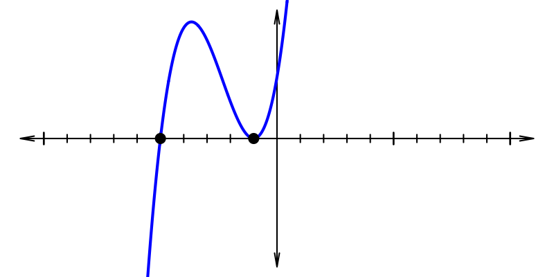

Which function matches Graph 1?

- $A(x)~=~(x-1)(x+5)$
- $B(x)~=~-(x+1)^{2}(x-5)$
- $C(x)~=~(x+1)^{2}(x+5)$
- $D(x)~=~(x+1)^{2}(x+5)^{2}$

### Graph 2

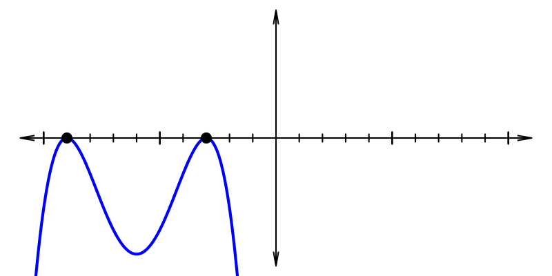

Which function matches Graph 2?

- $A(x)~=~(x-3)(x-9)^{2}$
- $B(x)~=~(x-3)^{2}(x+9)^{2}$
- $C(x)~=~-(x+3)^{2}(x+9)^{2}$
- $D(x)~=~(x+3)^{2}(x+9)^{2}$

### Graph 3

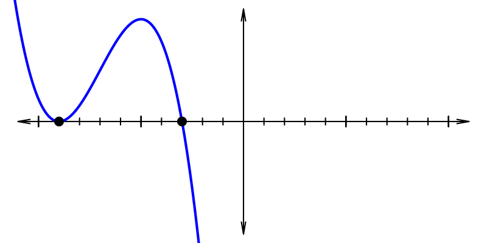

Which function matches Graph 3?

- $A(x)~=~-(x-3)(x-9)$
- $B(x)~=~(x-3)(x+9)$
- $C(x)~=~(x+3)(x+9)$
- $D(x)~=~-(x+3)(x+9)^{2}$
- Graph 1 is $C(x)~=~(x+1)^{2}(x+5)$
- Graph 2 is $C(x)~=~-(x+3)^{2}(x+9)^{2}$
- Graph 3 is $D(x)~=~-(x+3)(x+9)^{2}$

Remember, each factor is $(x-r)$ where $r$ is the root. If the factor is squared, we expect a bounce. Lastly, make sure to pay attention to the sign in front, which will dictate the end behavior.

### Graph 1

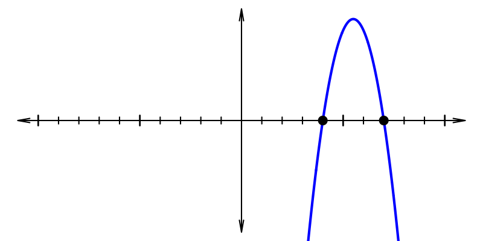

Which function matches Graph 1?

- $A(x)~=~-(x-4)(x-7)$
- $B(x)~=~(x-4)(x-7)^{2}$
- $C(x)~=~-(x-4)(x+7)$
- $D(x)~=~(x+4)(x+7)$

### Graph 2

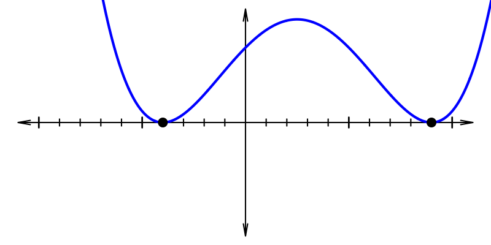

Which function matches Graph 2?

- $A(x)~=~-(x-4)^{2}(x+9)$
- $B(x)~=~(x+4)^{2}(x-9)^{2}$
- $C(x)~=~-(x+4)(x+9)$
- $D(x)~=~(x+4)(x+9)$

### Graph 3

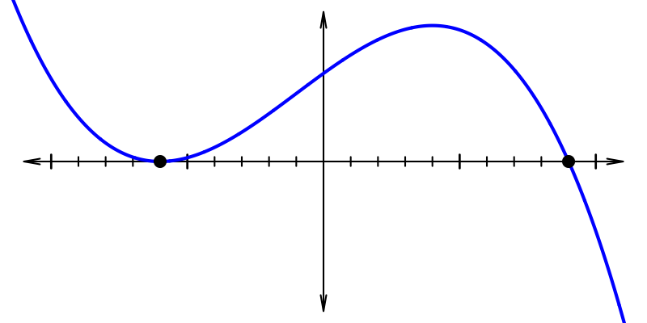

Which function matches Graph 3?

- $A(x)~=~-(x-6)^{2}(x-9)$
- $B(x)~=~-(x+6)^{2}(x-9)$
- $C(x)~=~-(x+6)(x+9)^{2}$
- $D(x)~=~(x+6)(x+9)^{2}$
- Graph 1 is $A(x)~=~-(x-4)(x-7)$
- Graph 2 is $B(x)~=~(x+4)^{2}(x-9)^{2}$
- Graph 3 is $B(x)~=~-(x+6)^{2}(x-9)$

Remember, each factor is $(x-r)$ where $r$ is the root. If the factor is squared, we expect a bounce. Lastly, make sure to pay attention to the sign in front, which will dictate the end behavior.

### Graph 1

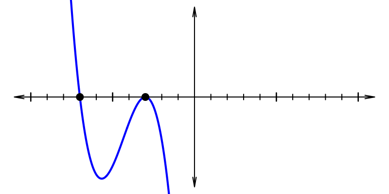

Which function matches Graph 1?

- $A(x)~=~(x-3)(x-7)$
- $B(x)~=~(x-3)(x+7)$
- $C(x)~=~-(x+3)(x-7)$
- $D(x)~=~-(x+3)^{2}(x+7)$

### Graph 2

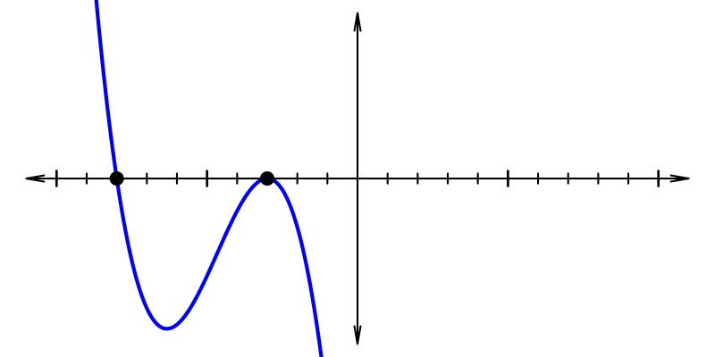

Which function matches Graph 2?

- $A(x)~=~(x-3)(x-8)$
- $B(x)~=~(x+3)^{2}(x-8)^{2}$
- $C(x)~=~-(x+3)(x+8)^{2}$
- $D(x)~=~-(x+3)^{2}(x+8)$

### Graph 3

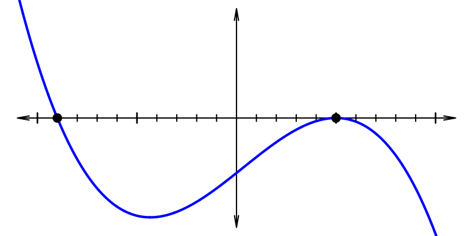

Which function matches Graph 3?

- $A(x)~=~(x-5)(x+9)^{2}$
- $B(x)~=~-(x-5)^{2}(x+9)$
- $C(x)~=~-(x+5)(x+9)^{2}$
- $D(x)~=~(x+5)^{2}(x+9)$
- Graph 1 is $D(x)~=~-(x+3)^{2}(x+7)$
- Graph 2 is $D(x)~=~-(x+3)^{2}(x+8)$
- Graph 3 is $B(x)~=~-(x-5)^{2}(x+9)$

Remember, each factor is $(x-r)$ where $r$ is the root. If the factor is squared, we expect a bounce. Lastly, make sure to pay attention to the sign in front, which will dictate the end behavior.

### Graph 1

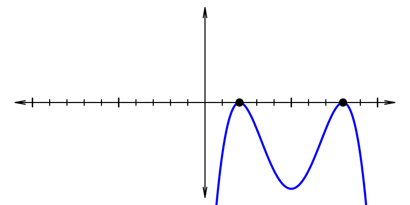

Which function matches Graph 1?

- $A(x)~=~(x-2)(x-8)^{2}$
- $B(x)~=~-(x-2)^{2}(x-8)^{2}$
- $C(x)~=~-(x-2)^{2}(x+8)$
- $D(x)~=~-(x+2)(x-8)$

### Graph 2

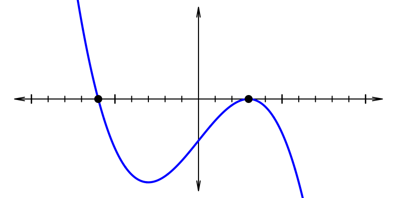

Which function matches Graph 2?

- $A(x)~=~-(x-3)(x+6)^{2}$
- $B(x)~=~-(x-3)^{2}(x+6)$
- $C(x)~=~-(x-3)^{2}(x+6)^{2}$
- $D(x)~=~(x+3)(x-6)^{2}$

### Graph 3

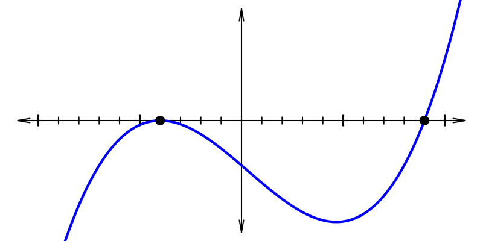

Which function matches Graph 3?

- $A(x)~=~(x-4)(x-9)$
- $B(x)~=~-(x-4)^{2}(x+9)^{2}$
- $C(x)~=~(x+4)^{2}(x-9)$
- $D(x)~=~(x+4)^{2}(x-9)^{2}$
- Graph 1 is $B(x)~=~-(x-2)^{2}(x-8)^{2}$
- Graph 2 is $B(x)~=~-(x-3)^{2}(x+6)$
- Graph 3 is $C(x)~=~(x+4)^{2}(x-9)$

Remember, each factor is $(x-r)$ where $r$ is the root. If the factor is squared, we expect a bounce. Lastly, make sure to pay attention to the sign in front, which will dictate the end behavior.

### Graph 1

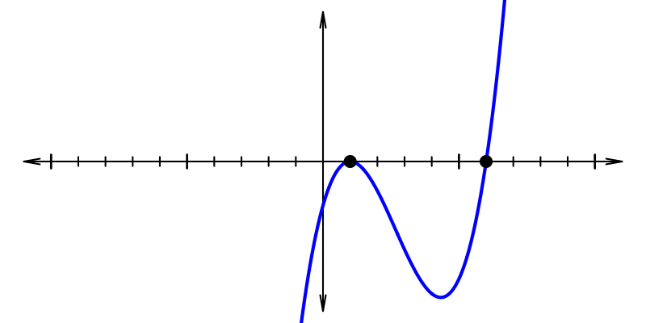

Which function matches Graph 1?

- $A(x)~=~(x-1)(x-6)$
- $B(x)~=~(x-1)^{2}(x-6)$
- $C(x)~=~(x-1)^{2}(x+6)^{2}$
- $D(x)~=~(x+1)^{2}(x+6)$

### Graph 2

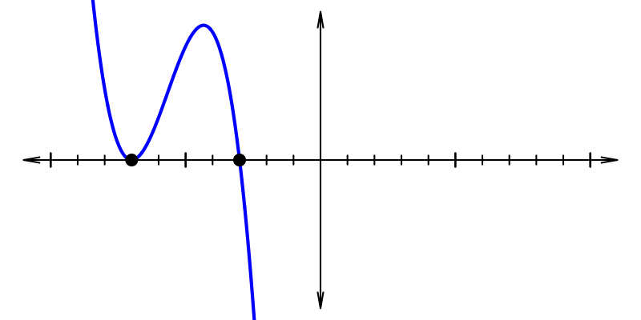

Which function matches Graph 2?

- $A(x)~=~-(x-3)^{2}(x+7)$
- $B(x)~=~-(x-3)^{2}(x+7)^{2}$
- $C(x)~=~(x+3)^{2}(x-7)$
- $D(x)~=~-(x+3)(x+7)^{2}$

### Graph 3

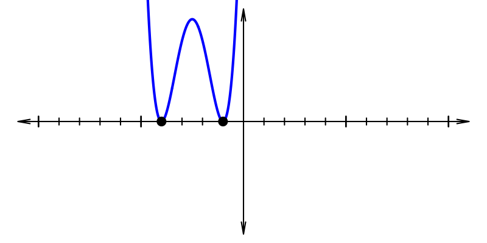

Which function matches Graph 3?

- $A(x)~=~-(x-1)(x+4)^{2}$
- $B(x)~=~-(x-1)^{2}(x+4)$
- $C(x)~=~-(x+1)^{2}(x+4)$
- $D(x)~=~(x+1)^{2}(x+4)^{2}$
- Graph 1 is $B(x)~=~(x-1)^{2}(x-6)$
- Graph 2 is $D(x)~=~-(x+3)(x+7)^{2}$
- Graph 3 is $D(x)~=~(x+1)^{2}(x+4)^{2}$

Remember, each factor is $(x-r)$ where $r$ is the root. If the factor is squared, we expect a bounce. Lastly, make sure to pay attention to the sign in front, which will dictate the end behavior.

### Graph 1

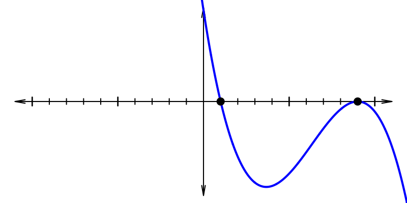

Which function matches Graph 1?

- $A(x)~=~-(x-1)(x-9)^{2}$
- $B(x)~=~(x+1)(x-9)$
- $C(x)~=~(x+1)(x+9)^{2}$
- $D(x)~=~(x+1)^{2}(x+9)$

### Graph 2

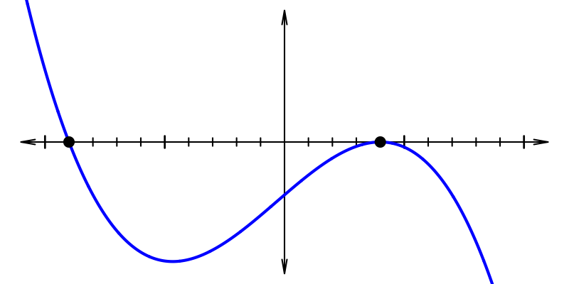

Which function matches Graph 2?

- $A(x)~=~-(x-4)^{2}(x+9)$
- $B(x)~=~(x+4)(x-9)^{2}$
- $C(x)~=~-(x+4)^{2}(x-9)^{2}$
- $D(x)~=~(x+4)^{2}(x-9)^{2}$

### Graph 3

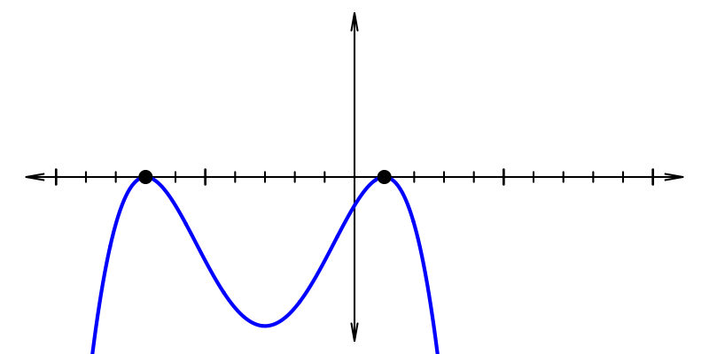

Which function matches Graph 3?

- $A(x)~=~-(x-1)(x-7)^{2}$
- $B(x)~=~-(x-1)^{2}(x+7)^{2}$
- $C(x)~=~(x+1)^{2}(x-7)^{2}$
- $D(x)~=~(x+1)^{2}(x+7)$
- Graph 1 is $A(x)~=~-(x-1)(x-9)^{2}$
- Graph 2 is $A(x)~=~-(x-4)^{2}(x+9)$
- Graph 3 is $B(x)~=~-(x-1)^{2}(x+7)^{2}$

Remember, each factor is $(x-r)$ where $r$ is the root. If the factor is squared, we expect a bounce. Lastly, make sure to pay attention to the sign in front, which will dictate the end behavior.

### Graph 1

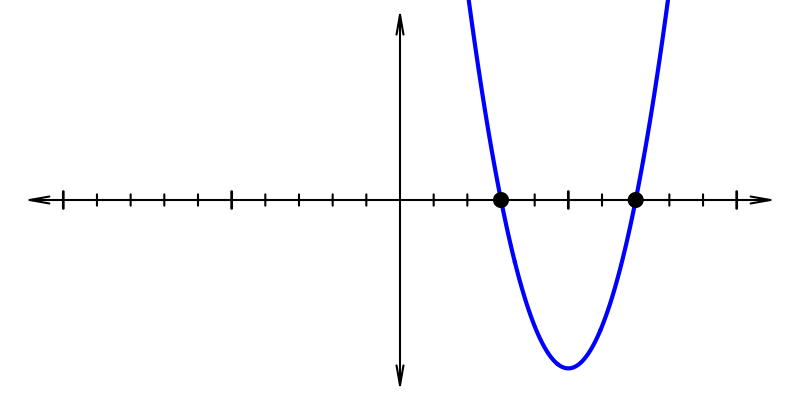

Which function matches Graph 1?

- $A(x)~=~(x-3)(x-7)$
- $B(x)~=~-(x-3)^{2}(x-7)$
- $C(x)~=~(x-3)(x+7)$
- $D(x)~=~(x+3)(x+7)$

### Graph 2

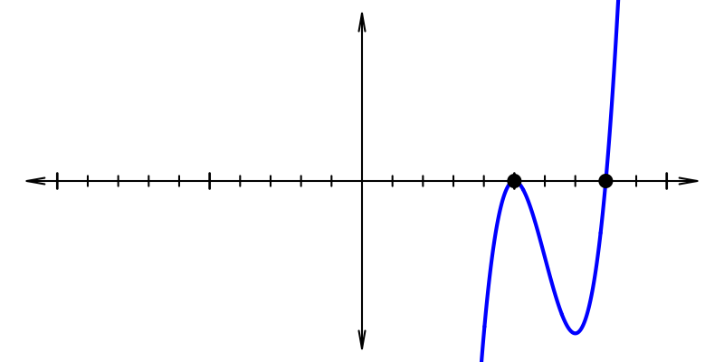

Which function matches Graph 2?

- $A(x)~=~(x-5)^{2}(x-8)$
- $B(x)~=~-(x-5)^{2}(x-8)^{2}$
- $C(x)~=~-(x-5)^{2}(x+8)^{2}$
- $D(x)~=~(x+5)(x+8)$